# Using wetlandHTLN R pkg.

## Using the wetlandHTLN R package

### Getting started

#### **Step 1.** Install R, RStudio, and RTools45 in Company Portal

#### **Step 2.** Install pak package in R:

```r
install.packages('pak')
```

#### **Step 3.** Install wetlandHTLN from GitHub

Note that whenever the `wetlandHTLN` package is updated, you can rerun this code to install the latest version.

```r
library(pak)
pkg_install("doi-nps/wetlandHTLN")
```

#### **Step 4.** Load wetlandHTLN R package

```r
library(wetlandHTLN)
```

#### **Step 5.** Import wetland monitoring data

Note that R is not able to connect to files on Sharepoint or MS Teams (b/c Teams also stores all files on Sharepoint). That means you need to store the database (and eventually the data package files) on your local machine, OneDrive, or HTLN server. The `importData()` function defaults are to import required data tables from the HTLN_wetlands Access database and then compile the data package views (i.e. flatfiles) for use with the R package. Using the default settings requires the `DBI` and `odbc` packages to be installed, and users must have MS Access installed on their computer. If those packages aren’t installed, you’ll get an error message in the console asking you to install them. Once the data package is published, I’ll add importing data package views as an option in this function, which then will not require MS Access or the `DBI` and `odbc` packages.

To keep your workspace clean (i.e. the top right panel with the Environment tab) in R, the default setting for `importData()` is to import data files into an environment called HTLN_wetlands. If you would rather import each individual view into your R session, specify with the new_env argument (e.g., `importData(new_env = F)`). To import data using the default settings (i.e. run `importData()` with no arguments), you must have the HTLN_wetlands access database set as a User DSN called HTLN_wetlands (see “Setting up DSN” tab for more details).

Currently, the `importData()` function only imports views related to the VIBI. Over time, options to compile/import views for ORAM and hydrology will be added.

**Option 1.** Import data using default settings, which imports from DSN named **HTLN_wetlands**.

```r
#install.packages(c('odbc', 'DBI')) # Only run if not already installed.

importData()
importData(type = "DSN", odbc = "HTLN_wetlands", data_type = "vibi") # equivalent to previous line
```

**Option 2.** Import data from a specified database.

```r
importData(type ='dbfile',
   filepath = '../data/HTLNwetlands3.5.2.accdb')
```

Additional import options will be added as the data package is completed for VIBI, and as ORAM and hydrology import features are added, including the ability to export views as csvs and/or a zipped file containing csvs.

#### **Step 6.** Play with the data

The functions in the `wetlandHTLN` package are designed to work with the views, and are the best way to interact with the data to query by park, site, site type, year, parameter, etc. However, if you want to view the raw data, and you imported the data into the HTLN_wetlands environment, you can access them with the code below:

```r
# See list of the views
names(HTLN_wetlands)

# Look at one of the views
View(HTLN_wetlands$herbVIBI)

# See top 6 records
head(HTLN_wetlands$herbVIBI)

# Check structure of view
str(HTLN_wetlands$woodyVIBI)

# Assign a view to a data frame named herbs in R. Interact with herbs the way you would work with any normal data frame in R.
herbs <- HTLN_wetlands$herbVIBI
```

While this works, the better approach is to use the “getter” functions within the R package, which access the same files, but allow you to also query data based on park, location, years, plot name, species, etc. See the specific getter function tabs for details.

If you want to use the `print_head()` function that shows output in this markdown, run the code below. This makes the results print cleaner in the markdown report. For your purposes, you can just run: `head(dataframe)`.

```r
print_head <- function(df){
    max_row <- ifelse(nrow(df) > 6, 6, nrow(df))
    knitr::kable(df[1:max_row,]) |> #, table.attr = "style='width:60%;'") |>
    kableExtra::kable_classic(full_width = F, font_size = 12,
                              bootstrap_options = c("condensed"))
}
```

#### **Getting (and improving) help**

You can also see the help of a function by running, for example:

```r
?importData
```

If `wetlandHTLN` isn’t loaded yet, you’d run:

```r
?wetlandHTLN::importData
```

Each function’s help includes a Description, Usage (i.e. function arguments and their defaults), Argument options/definitions, and several examples showing how the function can be used.

**This is where you come in! If you notice typos or can think of better descriptions, examples, error messages, etc., please send them my way!** After we’re more comfortable with R packages and get versed on GitHub, you’ll be able to make those changes directly in the package. For now, you can just send me your suggestions and I’ll make the changes.

Finally, if you ever want to peak under the hood at the function, you can view it several ways.

1. Keep F2 key pressed and click on the function name in R. This trick works for many but not all functions in R.
2. View code in the [GitHub doi-nps/wetlandHTLN repo](https://github.com/doi-nps/wetlandHTLN/tree/main). The functions are in the R folder.

#### **Setting up a DSN**

1. Go to Windows Start Menu and search ODBC. Click on ODBC Data Sources (64-bit)

[figure not shown]

2. Click on *Add*, then select *Microsoft Access Driver (*.mdb, *.accdb)* then click *Finish* in next menu.

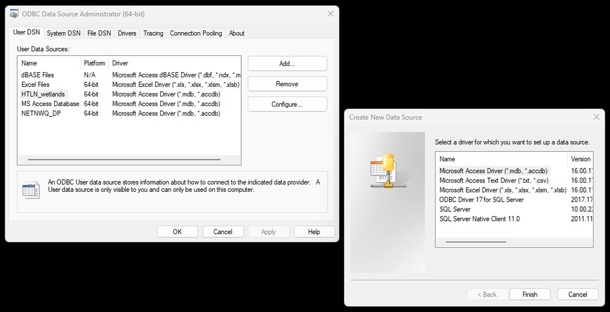

3. Enter **HTLN_wetlands** into the Data Source Name (red arrow), click on Select (red circle). In the new window find the path to your database in the upper right. Click on the database (yellow arrow), then click OK. Finally, add the name of the database file to the Description (blue arrow), so it’s easier to check whether you’re using the latest version.

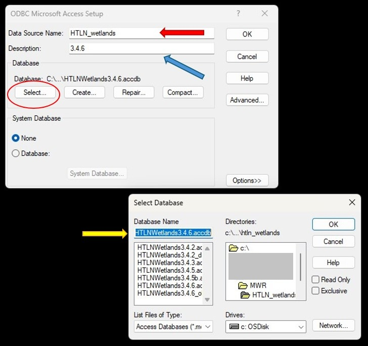

4. If updating an existing DSN, follow similar process, except click on the DSN in the first window and select *Configure* instead of Add.

### Get Data functions

#### getBigTrees()

This function filters big tree data (i.e. trees > 40cm DBH) by plot, year, plot types, dominant vegetation, and nativity.

Get Big Tree data using default settings that return all records.

```r
bigt <- getBigTrees()

print_head(bigt)
```

| LocationID | FeatureID | Park | County | PeriodYear | SampleDate | SampleYear | Latitude | Longitude | TotalMods | IntensMods | PlotConfig | AreaHA | X1oPlants | X1oHGM | DomVegID | HGM_ID | Mod_Desc | DomVeg_Lev1 | DomVeg_Lev2 | DomVeg_Lev3 | SurveyType | ScientificName | COMMON_NAME | AUTHORITY | FAMILY | ACRONYM | COFC | FN | WET | … |
| --- | --- | --- | --- | --- | --- | --- | --- | --- | --- | --- | --- | --- | --- | --- | --- | --- | --- | --- | --- | --- | --- | --- | --- | --- | --- | --- | --- | --- | --- | --- |
| CUVAWetlnd145 | 1049 | CUVA | Cuyahoga | 2008 | 2008-09-17 | 2008 | 4579001 | 449676.4 | 10 | 4 | 2x5 | 0.1 | PFO | RM | 1axi | NA | NA | forest | Swamp Forest | other (specify) | womc | Acer negundo | BOX ELDER | L. | Aceraceae | ACENEG | 3 | 2 | FAC+ | … |
| CUVAWetlnd145 | 1049 | CUVA | Cuyahoga | 2008 | 2008-09-17 | 2008 | 4579001 | 449676.4 | 10 | 4 | 2x5 | 0.1 | PFO | RM | 1axi | NA | NA | forest | Swamp Forest | other (specify) | womc | Populus deltoides | EASTERN COTTONWOOD | W. Bartram ex Marshall | Salicaceae | POPDEL | 3 | 377 | FAC | … |
| CUVAWetlnd145 | 1049 | CUVA | Cuyahoga | 2008 | 2008-09-17 | 2008 | 4579001 | 449676.4 | 10 | 4 | 2x5 | 0.1 | PFO | RM | 1axi | NA | NA | forest | Swamp Forest | other (specify) | womc | Populus deltoides | EASTERN COTTONWOOD | W. Bartram ex Marshall | Salicaceae | POPDEL | 3 | 377 | FAC | … |
| CUVAWetlnd145 | 1049 | CUVA | Cuyahoga | 2008 | 2008-09-17 | 2008 | 4579001 | 449676.4 | 10 | 4 | 2x5 | 0.1 | PFO | RM | 1axi | NA | NA | forest | Swamp Forest | other (specify) | womc | Populus deltoides | EASTERN COTTONWOOD | W. Bartram ex Marshall | Salicaceae | POPDEL | 3 | 377 | FAC | … |
| CUVAWetlnd145 | 1049 | CUVA | Cuyahoga | 2008 | 2008-09-17 | 2008 | 4579001 | 449676.4 | 10 | 4 | 2x5 | 0.1 | PFO | RM | 1axi | NA | NA | forest | Swamp Forest | other (specify) | womc | Populus deltoides | EASTERN COTTONWOOD | W. Bartram ex Marshall | Salicaceae | POPDEL | 3 | 377 | FAC | … |
| CUVAWetlnd145 | 1049 | CUVA | Cuyahoga | 2008 | 2008-09-17 | 2008 | 4579001 | 449676.4 | 10 | 4 | 2x5 | 0.1 | PFO | RM | 1axi | NA | NA | forest | Swamp Forest | other (specify) | womc | Populus deltoides | EASTERN COTTONWOOD | W. Bartram ex Marshall | Salicaceae | POPDEL | 3 | 377 | FAC | … |

Return only 2023 data

```r
bigtree23 <- getBigTrees(years = 2023)

print_head(bigtree23)
```

| LocationID | FeatureID | Park | County | PeriodYear | SampleDate | SampleYear | Latitude | Longitude | TotalMods | IntensMods | PlotConfig | AreaHA | X1oPlants | X1oHGM | DomVegID | HGM_ID | Mod_Desc | DomVeg_Lev1 | DomVeg_Lev2 | DomVeg_Lev3 | SurveyType | ScientificName | COMMON_NAME | AUTHORITY | FAMILY | ACRONYM | COFC | FN | WET | … |
| --- | --- | --- | --- | --- | --- | --- | --- | --- | --- | --- | --- | --- | --- | --- | --- | --- | --- | --- | --- | --- | --- | --- | --- | --- | --- | --- | --- | --- | --- | --- |
| CUVAWetlnd136 | 526 | CUVA | Summit | 2023 | 2023-08-01 | 2023 | 4567140 | 454408.7 | 10 | 4 | 2x5 | 0.1 | PEM | SP | 2biv | NA | NA | emergent | Wet Meadow | fen | womc, reference | Standing dead | ND | ND | NA | STNDEAD | NA | NA | ND | … |
| CUVAWetlnd136 | 526 | CUVA | Summit | 2023 | 2023-08-01 | 2023 | 4567140 | 454408.7 | 10 | 4 | 2x5 | 0.1 | PEM | SP | 2biv | NA | NA | emergent | Wet Meadow | fen | womc, reference | Standing dead | ND | ND | NA | STNDEAD | NA | NA | ND | … |
| CUVAWetlnd136 | 526 | CUVA | Summit | 2023 | 2023-08-01 | 2023 | 4567140 | 454408.7 | 10 | 4 | 2x5 | 0.1 | PEM | SP | 2biv | NA | NA | emergent | Wet Meadow | fen | womc, reference | Standing dead | ND | ND | NA | STNDEAD | NA | NA | ND | … |
| CUVAWetlnd136 | 526 | CUVA | Summit | 2023 | 2023-08-01 | 2023 | 4567140 | 454408.7 | 10 | 4 | 2x5 | 0.1 | PEM | SP | 2biv | NA | NA | emergent | Wet Meadow | fen | womc, reference | Standing dead | ND | ND | NA | STNDEAD | NA | NA | ND | … |
| CUVAWetlnd136 | 526 | CUVA | Summit | 2023 | 2023-08-01 | 2023 | 4567140 | 454408.7 | 10 | 4 | 2x5 | 0.1 | PEM | SP | 2biv | NA | NA | emergent | Wet Meadow | fen | womc, reference | Standing dead | ND | ND | NA | STNDEAD | NA | NA | ND | … |
| CUVAWetlnd136 | 526 | CUVA | Summit | 2023 | 2023-08-01 | 2023 | 4567140 | 454408.7 | 10 | 4 | 2x5 | 0.1 | PEM | SP | 2biv | NA | NA | emergent | Wet Meadow | fen | womc, reference | Standing dead | ND | ND | NA | STNDEAD | NA | NA | ND | … |

Return 2020 and later

```r
bigtree20 <- getBigTrees(years = 2020:2024)

print_head(bigtree20)
```

| LocationID | FeatureID | Park | County | PeriodYear | SampleDate | SampleYear | Latitude | Longitude | TotalMods | IntensMods | PlotConfig | AreaHA | X1oPlants | X1oHGM | DomVegID | HGM_ID | Mod_Desc | DomVeg_Lev1 | DomVeg_Lev2 | DomVeg_Lev3 | SurveyType | ScientificName | COMMON_NAME | AUTHORITY | FAMILY | ACRONYM | COFC | FN | WET | … |
| --- | --- | --- | --- | --- | --- | --- | --- | --- | --- | --- | --- | --- | --- | --- | --- | --- | --- | --- | --- | --- | --- | --- | --- | --- | --- | --- | --- | --- | --- | --- |
| CUVAWetlnd196 | 676 | CUVA | Summit | 2020 | 2020-08-03 | 2020 | 4566435 | 455713.4 | 6 | 4 | 2x3 | 0.06 | PFO | DP | 1ai | IB | Ground water (seasonal to permanent input) | forest | Swamp Forest | oak-maple | survey | Quercus bicolor | SWAMP WHITE OAK | Willd. | Fagaceae | QUEBIC | 7 | NA | FACW+ | … |
| CUVAWetlnd196 | 676 | CUVA | Summit | 2020 | 2020-08-03 | 2020 | 4566435 | 455713.4 | 6 | 4 | 2x3 | 0.06 | PFO | DP | 1ai | IB | Ground water (seasonal to permanent input) | forest | Swamp Forest | oak-maple | survey | Quercus bicolor | SWAMP WHITE OAK | Willd. | Fagaceae | QUEBIC | 7 | NA | FACW+ | … |
| CUVAWetlnd196 | 676 | CUVA | Summit | 2020 | 2020-08-03 | 2020 | 4566435 | 455713.4 | 6 | 4 | 2x3 | 0.06 | PFO | DP | 1ai | IB | Ground water (seasonal to permanent input) | forest | Swamp Forest | oak-maple | survey | Quercus bicolor | SWAMP WHITE OAK | Willd. | Fagaceae | QUEBIC | 7 | NA | FACW+ | … |
| CUVAWetlnd196 | 676 | CUVA | Summit | 2020 | 2020-08-03 | 2020 | 4566435 | 455713.4 | 6 | 4 | 2x3 | 0.06 | PFO | DP | 1ai | IB | Ground water (seasonal to permanent input) | forest | Swamp Forest | oak-maple | survey | Quercus bicolor | SWAMP WHITE OAK | Willd. | Fagaceae | QUEBIC | 7 | NA | FACW+ | … |
| CUVAWetlnd199 | 743 | CUVA | Cuyahoga | 2020 | 2020-08-04 | 2020 | 4570066 | 450104.7 | 4 | 4 | 1x4 | 0.04 | PFO | RH | 1ai | IIIA | Headwater depression (1st or 2nd order) | forest | Swamp Forest | oak-maple | survey | Salix nigra | BLACK WILLOW | Marshall | Salicaceae | SLXNIG | 2 | NA | FACW+ | … |
| CUVAWetlnd208 | 947 | CUVA | Cuyahoga | 2020 | 2020-08-04 | 2020 | 4574860 | 448800.0 | 4 | 4 | 2x2 | 0.04 | PEM | DP | 2bvi | IB | Ground water (seasonal to permanent input) | emergent | Wet Meadow | other (specify) | survey | Standing dead | ND | ND | NA | STNDEAD | NA | NA | ND | … |

Return only reference sites

```r
ref <- getBigTrees(survey_type = c("reference", "womc, reference"))

print_head(ref)
```

| LocationID | FeatureID | Park | County | PeriodYear | SampleDate | SampleYear | Latitude | Longitude | TotalMods | IntensMods | PlotConfig | AreaHA | X1oPlants | X1oHGM | DomVegID | HGM_ID | Mod_Desc | DomVeg_Lev1 | DomVeg_Lev2 | DomVeg_Lev3 | SurveyType | ScientificName | COMMON_NAME | AUTHORITY | FAMILY | ACRONYM | COFC | FN | WET | … |
| --- | --- | --- | --- | --- | --- | --- | --- | --- | --- | --- | --- | --- | --- | --- | --- | --- | --- | --- | --- | --- | --- | --- | --- | --- | --- | --- | --- | --- | --- | --- |
| CUVAWetlnd157 | 1427 | CUVA | Summit | 2014 | 2014-08-14 | 2014 | 4557258 | 451956.2 | 10 | 4 | 2x5 | 0.1 | PFO | RM | 1axi | NA | NA | forest | Swamp Forest | other (specify) | reference | Standing dead | ND | ND | NA | STNDEAD | NA | NA | ND | … |
| CUVAWetlnd157 | 1427 | CUVA | Summit | 2014 | 2014-08-14 | 2014 | 4557258 | 451956.2 | 10 | 4 | 2x5 | 0.1 | PFO | RM | 1axi | NA | NA | forest | Swamp Forest | other (specify) | reference | Populus deltoides | EASTERN COTTONWOOD | W. Bartram ex Marshall | Salicaceae | POPDEL | 3 | 377 | FAC | … |
| CUVAWetlnd157 | 1427 | CUVA | Summit | 2014 | 2014-08-14 | 2014 | 4557258 | 451956.2 | 10 | 4 | 2x5 | 0.1 | PFO | RM | 1axi | NA | NA | forest | Swamp Forest | other (specify) | reference | Acer saccharinum | SILVER MAPLE | L. | Aceraceae | ACESAC | 3 | NA | FACW | … |
| CUVAWetlnd157 | 1427 | CUVA | Summit | 2014 | 2014-08-14 | 2014 | 4557258 | 451956.2 | 10 | 4 | 2x5 | 0.1 | PFO | RM | 1axi | NA | NA | forest | Swamp Forest | other (specify) | reference | Populus deltoides | EASTERN COTTONWOOD | W. Bartram ex Marshall | Salicaceae | POPDEL | 3 | 377 | FAC | … |
| CUVAWetlnd157 | 1427 | CUVA | Summit | 2014 | 2014-08-14 | 2014 | 4557258 | 451956.2 | 10 | 4 | 2x5 | 0.1 | PFO | RM | 1axi | NA | NA | forest | Swamp Forest | other (specify) | reference | Acer saccharinum | SILVER MAPLE | L. | Aceraceae | ACESAC | 3 | NA | FACW | … |
| CUVAWetlnd157 | 1427 | CUVA | Summit | 2014 | 2014-08-14 | 2014 | 4557258 | 451956.2 | 10 | 4 | 2x5 | 0.1 | PFO | RM | 1axi | NA | NA | forest | Swamp Forest | other (specify) | reference | Populus deltoides | EASTERN COTTONWOOD | W. Bartram ex Marshall | Salicaceae | POPDEL | 3 | 377 | FAC | … |

Return only wetlands of management concern

```r
womc <- getBigTrees(survey_type = c("womc", "womc, reference", "survey, womc"))

print_head(womc)
```

| LocationID | FeatureID | Park | County | PeriodYear | SampleDate | SampleYear | Latitude | Longitude | TotalMods | IntensMods | PlotConfig | AreaHA | X1oPlants | X1oHGM | DomVegID | HGM_ID | Mod_Desc | DomVeg_Lev1 | DomVeg_Lev2 | DomVeg_Lev3 | SurveyType | ScientificName | COMMON_NAME | AUTHORITY | FAMILY | ACRONYM | COFC | FN | WET | … |
| --- | --- | --- | --- | --- | --- | --- | --- | --- | --- | --- | --- | --- | --- | --- | --- | --- | --- | --- | --- | --- | --- | --- | --- | --- | --- | --- | --- | --- | --- | --- |
| CUVAWetlnd145 | 1049 | CUVA | Cuyahoga | 2008 | 2008-09-17 | 2008 | 4579001 | 449676.4 | 10 | 4 | 2x5 | 0.1 | PFO | RM | 1axi | NA | NA | forest | Swamp Forest | other (specify) | womc | Acer negundo | BOX ELDER | L. | Aceraceae | ACENEG | 3 | 2 | FAC+ | … |
| CUVAWetlnd145 | 1049 | CUVA | Cuyahoga | 2008 | 2008-09-17 | 2008 | 4579001 | 449676.4 | 10 | 4 | 2x5 | 0.1 | PFO | RM | 1axi | NA | NA | forest | Swamp Forest | other (specify) | womc | Populus deltoides | EASTERN COTTONWOOD | W. Bartram ex Marshall | Salicaceae | POPDEL | 3 | 377 | FAC | … |
| CUVAWetlnd145 | 1049 | CUVA | Cuyahoga | 2008 | 2008-09-17 | 2008 | 4579001 | 449676.4 | 10 | 4 | 2x5 | 0.1 | PFO | RM | 1axi | NA | NA | forest | Swamp Forest | other (specify) | womc | Populus deltoides | EASTERN COTTONWOOD | W. Bartram ex Marshall | Salicaceae | POPDEL | 3 | 377 | FAC | … |
| CUVAWetlnd145 | 1049 | CUVA | Cuyahoga | 2008 | 2008-09-17 | 2008 | 4579001 | 449676.4 | 10 | 4 | 2x5 | 0.1 | PFO | RM | 1axi | NA | NA | forest | Swamp Forest | other (specify) | womc | Populus deltoides | EASTERN COTTONWOOD | W. Bartram ex Marshall | Salicaceae | POPDEL | 3 | 377 | FAC | … |
| CUVAWetlnd145 | 1049 | CUVA | Cuyahoga | 2008 | 2008-09-17 | 2008 | 4579001 | 449676.4 | 10 | 4 | 2x5 | 0.1 | PFO | RM | 1axi | NA | NA | forest | Swamp Forest | other (specify) | womc | Populus deltoides | EASTERN COTTONWOOD | W. Bartram ex Marshall | Salicaceae | POPDEL | 3 | 377 | FAC | … |
| CUVAWetlnd145 | 1049 | CUVA | Cuyahoga | 2008 | 2008-09-17 | 2008 | 4579001 | 449676.4 | 10 | 4 | 2x5 | 0.1 | PFO | RM | 1axi | NA | NA | forest | Swamp Forest | other (specify) | womc | Populus deltoides | EASTERN COTTONWOOD | W. Bartram ex Marshall | Salicaceae | POPDEL | 3 | 377 | FAC | … |

Return only depressional wetlands

```r
dep <- getBigTrees(hgm_class = c("Depression"))

print_head(dep)
```

| LocationID | FeatureID | Park | County | PeriodYear | SampleDate | SampleYear | Latitude | Longitude | TotalMods | IntensMods | PlotConfig | AreaHA | X1oPlants | X1oHGM | DomVegID | HGM_ID | Mod_Desc | DomVeg_Lev1 | DomVeg_Lev2 | DomVeg_Lev3 | SurveyType | ScientificName | COMMON_NAME | AUTHORITY | FAMILY | ACRONYM | COFC | FN | WET | … |
| --- | --- | --- | --- | --- | --- | --- | --- | --- | --- | --- | --- | --- | --- | --- | --- | --- | --- | --- | --- | --- | --- | --- | --- | --- | --- | --- | --- | --- | --- | --- |
| CUVAWetlnd196 | 676 | CUVA | Summit | NA | 2015-07-16 | 2015 | 4566435 | 455713.4 | 6 | 4 | 2x3 | 0.06 | PFO | DP | 1ai | IB | Ground water (seasonal to permanent input) | forest | Swamp Forest | oak-maple | survey | Quercus bicolor | SWAMP WHITE OAK | Willd. | Fagaceae | QUEBIC | 7 | NA | FACW+ | … |
| CUVAWetlnd196 | 676 | CUVA | Summit | NA | 2015-07-16 | 2015 | 4566435 | 455713.4 | 6 | 4 | 2x3 | 0.06 | PFO | DP | 1ai | IB | Ground water (seasonal to permanent input) | forest | Swamp Forest | oak-maple | survey | Quercus bicolor | SWAMP WHITE OAK | Willd. | Fagaceae | QUEBIC | 7 | NA | FACW+ | … |
| CUVAWetlnd196 | 676 | CUVA | Summit | NA | 2015-07-16 | 2015 | 4566435 | 455713.4 | 6 | 4 | 2x3 | 0.06 | PFO | DP | 1ai | IB | Ground water (seasonal to permanent input) | forest | Swamp Forest | oak-maple | survey | Quercus bicolor | SWAMP WHITE OAK | Willd. | Fagaceae | QUEBIC | 7 | NA | FACW+ | … |
| CUVAWetlnd196 | 676 | CUVA | Summit | NA | 2015-07-16 | 2015 | 4566435 | 455713.4 | 6 | 4 | 2x3 | 0.06 | PFO | DP | 1ai | IB | Ground water (seasonal to permanent input) | forest | Swamp Forest | oak-maple | survey | Quercus bicolor | SWAMP WHITE OAK | Willd. | Fagaceae | QUEBIC | 7 | NA | FACW+ | … |
| CUVAWetlnd194 | 628 | CUVA | Summit | NA | 2015-06-25 | 2015 | 4566936 | 456457.0 | 10 | 4 | 2x5 | 0.1 | PFO | DP | 1aii | IA | Surface water Depression (sheet flow, precipitation) | forest | Swamp Forest | oak-maple-ash | survey | Acer rubrum | RED MAPLE | L. | Aceraceae | ACERUB | 2 | 3 | FAC | … |
| CUVAWetlnd194 | 628 | CUVA | Summit | NA | 2015-06-25 | 2015 | 4566936 | 456457.0 | 10 | 4 | 2x5 | 0.1 | PFO | DP | 1aii | IA | Surface water Depression (sheet flow, precipitation) | forest | Swamp Forest | oak-maple-ash | survey | Fraxinus pennsylvanica | GREEN ASH | Marshall | Oleaceae | FRAPEN | 3 | 236 | FACW | … |

Return only forested sites

```r
forest <- getBigTrees(dom_veg1 = "forest")

print_head(forest)
```

| LocationID | FeatureID | Park | County | PeriodYear | SampleDate | SampleYear | Latitude | Longitude | TotalMods | IntensMods | PlotConfig | AreaHA | X1oPlants | X1oHGM | DomVegID | HGM_ID | Mod_Desc | DomVeg_Lev1 | DomVeg_Lev2 | DomVeg_Lev3 | SurveyType | ScientificName | COMMON_NAME | AUTHORITY | FAMILY | ACRONYM | COFC | FN | WET | … |
| --- | --- | --- | --- | --- | --- | --- | --- | --- | --- | --- | --- | --- | --- | --- | --- | --- | --- | --- | --- | --- | --- | --- | --- | --- | --- | --- | --- | --- | --- | --- |
| CUVAWetlnd145 | 1049 | CUVA | Cuyahoga | 2008 | 2008-09-17 | 2008 | 4579001 | 449676.4 | 10 | 4 | 2x5 | 0.1 | PFO | RM | 1axi | NA | NA | forest | Swamp Forest | other (specify) | womc | Acer negundo | BOX ELDER | L. | Aceraceae | ACENEG | 3 | 2 | FAC+ | … |
| CUVAWetlnd145 | 1049 | CUVA | Cuyahoga | 2008 | 2008-09-17 | 2008 | 4579001 | 449676.4 | 10 | 4 | 2x5 | 0.1 | PFO | RM | 1axi | NA | NA | forest | Swamp Forest | other (specify) | womc | Populus deltoides | EASTERN COTTONWOOD | W. Bartram ex Marshall | Salicaceae | POPDEL | 3 | 377 | FAC | … |
| CUVAWetlnd145 | 1049 | CUVA | Cuyahoga | 2008 | 2008-09-17 | 2008 | 4579001 | 449676.4 | 10 | 4 | 2x5 | 0.1 | PFO | RM | 1axi | NA | NA | forest | Swamp Forest | other (specify) | womc | Populus deltoides | EASTERN COTTONWOOD | W. Bartram ex Marshall | Salicaceae | POPDEL | 3 | 377 | FAC | … |
| CUVAWetlnd145 | 1049 | CUVA | Cuyahoga | 2008 | 2008-09-17 | 2008 | 4579001 | 449676.4 | 10 | 4 | 2x5 | 0.1 | PFO | RM | 1axi | NA | NA | forest | Swamp Forest | other (specify) | womc | Populus deltoides | EASTERN COTTONWOOD | W. Bartram ex Marshall | Salicaceae | POPDEL | 3 | 377 | FAC | … |
| CUVAWetlnd145 | 1049 | CUVA | Cuyahoga | 2008 | 2008-09-17 | 2008 | 4579001 | 449676.4 | 10 | 4 | 2x5 | 0.1 | PFO | RM | 1axi | NA | NA | forest | Swamp Forest | other (specify) | womc | Populus deltoides | EASTERN COTTONWOOD | W. Bartram ex Marshall | Salicaceae | POPDEL | 3 | 377 | FAC | … |
| CUVAWetlnd145 | 1049 | CUVA | Cuyahoga | 2008 | 2008-09-17 | 2008 | 4579001 | 449676.4 | 10 | 4 | 2x5 | 0.1 | PFO | RM | 1axi | NA | NA | forest | Swamp Forest | other (specify) | womc | Populus deltoides | EASTERN COTTONWOOD | W. Bartram ex Marshall | Salicaceae | POPDEL | 3 | 377 | FAC | … |

Return only native species

```r
nat <- getBigTrees(nativity = 'native')

print_head(nat)
```

| LocationID | FeatureID | Park | County | PeriodYear | SampleDate | SampleYear | Latitude | Longitude | TotalMods | IntensMods | PlotConfig | AreaHA | X1oPlants | X1oHGM | DomVegID | HGM_ID | Mod_Desc | DomVeg_Lev1 | DomVeg_Lev2 | DomVeg_Lev3 | SurveyType | ScientificName | COMMON_NAME | AUTHORITY | FAMILY | ACRONYM | COFC | FN | WET | … |
| --- | --- | --- | --- | --- | --- | --- | --- | --- | --- | --- | --- | --- | --- | --- | --- | --- | --- | --- | --- | --- | --- | --- | --- | --- | --- | --- | --- | --- | --- | --- |
| CUVAWetlnd145 | 1049 | CUVA | Cuyahoga | 2008 | 2008-09-17 | 2008 | 4579001 | 449676.4 | 10 | 4 | 2x5 | 0.1 | PFO | RM | 1axi | NA | NA | forest | Swamp Forest | other (specify) | womc | Acer negundo | BOX ELDER | L. | Aceraceae | ACENEG | 3 | 2 | FAC+ | … |
| CUVAWetlnd145 | 1049 | CUVA | Cuyahoga | 2008 | 2008-09-17 | 2008 | 4579001 | 449676.4 | 10 | 4 | 2x5 | 0.1 | PFO | RM | 1axi | NA | NA | forest | Swamp Forest | other (specify) | womc | Populus deltoides | EASTERN COTTONWOOD | W. Bartram ex Marshall | Salicaceae | POPDEL | 3 | 377 | FAC | … |
| CUVAWetlnd145 | 1049 | CUVA | Cuyahoga | 2008 | 2008-09-17 | 2008 | 4579001 | 449676.4 | 10 | 4 | 2x5 | 0.1 | PFO | RM | 1axi | NA | NA | forest | Swamp Forest | other (specify) | womc | Populus deltoides | EASTERN COTTONWOOD | W. Bartram ex Marshall | Salicaceae | POPDEL | 3 | 377 | FAC | … |
| CUVAWetlnd145 | 1049 | CUVA | Cuyahoga | 2008 | 2008-09-17 | 2008 | 4579001 | 449676.4 | 10 | 4 | 2x5 | 0.1 | PFO | RM | 1axi | NA | NA | forest | Swamp Forest | other (specify) | womc | Populus deltoides | EASTERN COTTONWOOD | W. Bartram ex Marshall | Salicaceae | POPDEL | 3 | 377 | FAC | … |
| CUVAWetlnd145 | 1049 | CUVA | Cuyahoga | 2008 | 2008-09-17 | 2008 | 4579001 | 449676.4 | 10 | 4 | 2x5 | 0.1 | PFO | RM | 1axi | NA | NA | forest | Swamp Forest | other (specify) | womc | Populus deltoides | EASTERN COTTONWOOD | W. Bartram ex Marshall | Salicaceae | POPDEL | 3 | 377 | FAC | … |
| CUVAWetlnd145 | 1049 | CUVA | Cuyahoga | 2008 | 2008-09-17 | 2008 | 4579001 | 449676.4 | 10 | 4 | 2x5 | 0.1 | PFO | RM | 1axi | NA | NA | forest | Swamp Forest | other (specify) | womc | Populus deltoides | EASTERN COTTONWOOD | W. Bartram ex Marshall | Salicaceae | POPDEL | 3 | 377 | FAC | … |

Return data for a subset of plots

```r
pts <- getBigTrees(plotID = c("1007", "1017", "1034", "1036", "1043"))

print_head(pts)
```

| LocationID | FeatureID | Park | County | PeriodYear | SampleDate | SampleYear | Latitude | Longitude | TotalMods | IntensMods | PlotConfig | AreaHA | X1oPlants | X1oHGM | DomVegID | HGM_ID | Mod_Desc | DomVeg_Lev1 | DomVeg_Lev2 | DomVeg_Lev3 | SurveyType | ScientificName | COMMON_NAME | AUTHORITY | FAMILY | ACRONYM | COFC | FN | WET | … |
| --- | --- | --- | --- | --- | --- | --- | --- | --- | --- | --- | --- | --- | --- | --- | --- | --- | --- | --- | --- | --- | --- | --- | --- | --- | --- | --- | --- | --- | --- | --- |
| CUVAWetlnd215 | 1017 | CUVA | Cuyahoga | 2019 | 2019-09-23 | 2019 | 4580087 | 454069.8 | 3 | 3 | 1x3 | 0.03 | PEM | SP | 2bvi | IVA | Riverine | emergent | Wet Meadow | other (specify) | survey | Ulmus americana | AMERICAN ELM | L. | Ulmaceae | ULMAME | 2 | NA | FACW- | … |
| CUVAWetlnd214 | 1007 | CUVA | Cuyahoga | 2019 | 2019-09-26 | 2019 | 4580240 | 453053.0 | 4 | 4 | 2x2 | 0.04 | PEM | SP | 2bvi | IVA | Riverine | emergent | Wet Meadow | other (specify) | survey | Acer rubrum | RED MAPLE | L. | Aceraceae | ACERUB | 2 | 3 | FAC | … |
| CUVAWetlnd214 | 1007 | CUVA | Cuyahoga | 2025 | 2025-09-03 | 2025 | 4580240 | 453053.0 | 4 | 4 | 2x2 | 0.04 | PEM | SP | 2bvi | IVA | Riverine | emergent | Wet Meadow | other (specify) | survey | Acer rubrum | RED MAPLE | L. | Aceraceae | ACERUB | 2 | 3 | FAC | … |
| CUVAWetlnd215 | 1017 | CUVA | Cuyahoga | 2025 | 2025-09-04 | 2025 | 4580087 | 454069.8 | 3 | 3 | 1x3 | 0.03 | PEM | SP | 2bvi | IVA | Riverine | emergent | Wet Meadow | other (specify) | survey | Standing dead | ND | ND | NA | STNDEAD | NA | NA | ND | … |

#### getBiomass()

This function filters biomass data by plot, year, plot types, survey types, dominant vegetation, etc.

Get Biomass data using default settings that return all records.

```r
bmass <- getBiomass()

print_head(bmass)
```

| LocationID | FeatureID | Park | County | PeriodYear | SampleDate | SampleYear | Latitude | Longitude | TotalMods | IntensMods | PlotConfig | AreaHA | X1oPlants | X1oHGM | DomVegID | HGM_ID | Mod_Desc | DomVeg_Lev1 | DomVeg_Lev2 | DomVeg_Lev3 | SurveyType | VIBI_Herb_Biomass_ID | ModuleNo | Corner | DryWt_g | EventID | PeriodID | type | basisOfRecord |
| --- | --- | --- | --- | --- | --- | --- | --- | --- | --- | --- | --- | --- | --- | --- | --- | --- | --- | --- | --- | --- | --- | --- | --- | --- | --- | --- | --- | --- | --- |
| CUVAWetlnd143 | 1043 | CUVA | Cuyahoga | 2008 | 2008-08-27 | 2008 | 4578711 | 448684.9 | 4 | 4 | 2x2 | 0.04 | PEM | SP | 2bv | NA | NA | emergent | Wet Meadow | reed canary grass meadow | womc | 20 | 3 | 2 | 197 | CUVAWetlnd2008Aug27 | CUVAWetlnd2008Mar01 | Event | HumanObservation |
| CUVAWetlnd143 | 1043 | CUVA | Cuyahoga | 2008 | 2008-08-27 | 2008 | 4578711 | 448684.9 | 4 | 4 | 2x2 | 0.04 | PEM | SP | 2bv | NA | NA | emergent | Wet Meadow | reed canary grass meadow | womc | 21 | 8 | 2 | 237 | CUVAWetlnd2008Aug27 | CUVAWetlnd2008Mar01 | Event | HumanObservation |
| CUVAWetlnd143 | 1043 | CUVA | Cuyahoga | 2008 | 2008-08-27 | 2008 | 4578711 | 448684.9 | 4 | 4 | 2x2 | 0.04 | PEM | SP | 2bv | NA | NA | emergent | Wet Meadow | reed canary grass meadow | womc | 22 | 2 | 2 | 115 | CUVAWetlnd2008Aug27 | CUVAWetlnd2008Mar01 | Event | HumanObservation |
| CUVAWetlnd143 | 1043 | CUVA | Cuyahoga | 2008 | 2008-08-27 | 2008 | 4578711 | 448684.9 | 4 | 4 | 2x2 | 0.04 | PEM | SP | 2bv | NA | NA | emergent | Wet Meadow | reed canary grass meadow | womc | 23 | 3 | 4 | 69 | CUVAWetlnd2008Aug27 | CUVAWetlnd2008Mar01 | Event | HumanObservation |
| CUVAWetlnd143 | 1043 | CUVA | Cuyahoga | 2008 | 2008-08-27 | 2008 | 4578711 | 448684.9 | 4 | 4 | 2x2 | 0.04 | PEM | SP | 2bv | NA | NA | emergent | Wet Meadow | reed canary grass meadow | womc | 24 | 8 | 4 | 95 | CUVAWetlnd2008Aug27 | CUVAWetlnd2008Mar01 | Event | HumanObservation |
| CUVAWetlnd143 | 1043 | CUVA | Cuyahoga | 2008 | 2008-08-27 | 2008 | 4578711 | 448684.9 | 4 | 4 | 2x2 | 0.04 | PEM | SP | 2bv | NA | NA | emergent | Wet Meadow | reed canary grass meadow | womc | 25 | 9 | 2 | 222 | CUVAWetlnd2008Aug27 | CUVAWetlnd2008Mar01 | Event | HumanObservation |

Return only 2023 data

```r
bmass23 <- getBiomass(years = 2023)

print_head(bmass23)
```

|  | LocationID | FeatureID | Park | County | PeriodYear | SampleDate | SampleYear | Latitude | Longitude | TotalMods | IntensMods | PlotConfig | AreaHA | X1oPlants | X1oHGM | DomVegID | HGM_ID | Mod_Desc | DomVeg_Lev1 | DomVeg_Lev2 | DomVeg_Lev3 | SurveyType | VIBI_Herb_Biomass_ID | ModuleNo | Corner | DryWt_g | EventID | PeriodID | type | … |
| --- | --- | --- | --- | --- | --- | --- | --- | --- | --- | --- | --- | --- | --- | --- | --- | --- | --- | --- | --- | --- | --- | --- | --- | --- | --- | --- | --- | --- | --- | --- |
| 1018 | CUVAWetlnd136 | 526 | CUVA | Summit | 2023 | 2023-08-02 | 2023 | 4567140 | 454408.7 | 10 | 4 | 2x5 | 0.1 | PEM | SP | 2biv | NA | NA | emergent | Wet Meadow | fen | womc, reference | 820 | 2 | 2 | 11.1 | CUVAWetlnd2023Aug02 | CUVAWetlnd2023Jun01 | Event | … |
| 1019 | CUVAWetlnd136 | 526 | CUVA | Summit | 2023 | 2023-08-02 | 2023 | 4567140 | 454408.7 | 10 | 4 | 2x5 | 0.1 | PEM | SP | 2biv | NA | NA | emergent | Wet Meadow | fen | womc, reference | 821 | 2 | 4 | 27.9 | CUVAWetlnd2023Aug02 | CUVAWetlnd2023Jun01 | Event | … |
| 1020 | CUVAWetlnd136 | 526 | CUVA | Summit | 2023 | 2023-08-02 | 2023 | 4567140 | 454408.7 | 10 | 4 | 2x5 | 0.1 | PEM | SP | 2biv | NA | NA | emergent | Wet Meadow | fen | womc, reference | 822 | 3 | 2 | 8.4 | CUVAWetlnd2023Aug02 | CUVAWetlnd2023Jun01 | Event | … |
| 1021 | CUVAWetlnd136 | 526 | CUVA | Summit | 2023 | 2023-08-02 | 2023 | 4567140 | 454408.7 | 10 | 4 | 2x5 | 0.1 | PEM | SP | 2biv | NA | NA | emergent | Wet Meadow | fen | womc, reference | 823 | 3 | 4 | 16.0 | CUVAWetlnd2023Aug02 | CUVAWetlnd2023Jun01 | Event | … |
| 1022 | CUVAWetlnd136 | 526 | CUVA | Summit | 2023 | 2023-08-02 | 2023 | 4567140 | 454408.7 | 10 | 4 | 2x5 | 0.1 | PEM | SP | 2biv | NA | NA | emergent | Wet Meadow | fen | womc, reference | 824 | 8 | 2 | 45.3 | CUVAWetlnd2023Aug02 | CUVAWetlnd2023Jun01 | Event | … |
| 1023 | CUVAWetlnd136 | 526 | CUVA | Summit | 2023 | 2023-08-02 | 2023 | 4567140 | 454408.7 | 10 | 4 | 2x5 | 0.1 | PEM | SP | 2biv | NA | NA | emergent | Wet Meadow | fen | womc, reference | 825 | 8 | 4 | 25.5 | CUVAWetlnd2023Aug02 | CUVAWetlnd2023Jun01 | Event | … |

Return 2020 and later

```r
bmass20 <- getBiomass(years = 2020:2024)

print_head(bmass20)
```

|  | LocationID | FeatureID | Park | County | PeriodYear | SampleDate | SampleYear | Latitude | Longitude | TotalMods | IntensMods | PlotConfig | AreaHA | X1oPlants | X1oHGM | DomVegID | HGM_ID | Mod_Desc | DomVeg_Lev1 | DomVeg_Lev2 | DomVeg_Lev3 | SurveyType | VIBI_Herb_Biomass_ID | ModuleNo | Corner | DryWt_g | EventID | PeriodID | type | … |
| --- | --- | --- | --- | --- | --- | --- | --- | --- | --- | --- | --- | --- | --- | --- | --- | --- | --- | --- | --- | --- | --- | --- | --- | --- | --- | --- | --- | --- | --- | --- |
| 1018 | CUVAWetlnd136 | 526 | CUVA | Summit | 2023 | 2023-08-02 | 2023 | 4567140 | 454408.7 | 10 | 4 | 2x5 | 0.1 | PEM | SP | 2biv | NA | NA | emergent | Wet Meadow | fen | womc, reference | 820 | 2 | 2 | 11.1 | CUVAWetlnd2023Aug02 | CUVAWetlnd2023Jun01 | Event | … |
| 1019 | CUVAWetlnd136 | 526 | CUVA | Summit | 2023 | 2023-08-02 | 2023 | 4567140 | 454408.7 | 10 | 4 | 2x5 | 0.1 | PEM | SP | 2biv | NA | NA | emergent | Wet Meadow | fen | womc, reference | 821 | 2 | 4 | 27.9 | CUVAWetlnd2023Aug02 | CUVAWetlnd2023Jun01 | Event | … |
| 1020 | CUVAWetlnd136 | 526 | CUVA | Summit | 2023 | 2023-08-02 | 2023 | 4567140 | 454408.7 | 10 | 4 | 2x5 | 0.1 | PEM | SP | 2biv | NA | NA | emergent | Wet Meadow | fen | womc, reference | 822 | 3 | 2 | 8.4 | CUVAWetlnd2023Aug02 | CUVAWetlnd2023Jun01 | Event | … |
| 1021 | CUVAWetlnd136 | 526 | CUVA | Summit | 2023 | 2023-08-02 | 2023 | 4567140 | 454408.7 | 10 | 4 | 2x5 | 0.1 | PEM | SP | 2biv | NA | NA | emergent | Wet Meadow | fen | womc, reference | 823 | 3 | 4 | 16.0 | CUVAWetlnd2023Aug02 | CUVAWetlnd2023Jun01 | Event | … |
| 1022 | CUVAWetlnd136 | 526 | CUVA | Summit | 2023 | 2023-08-02 | 2023 | 4567140 | 454408.7 | 10 | 4 | 2x5 | 0.1 | PEM | SP | 2biv | NA | NA | emergent | Wet Meadow | fen | womc, reference | 824 | 8 | 2 | 45.3 | CUVAWetlnd2023Aug02 | CUVAWetlnd2023Jun01 | Event | … |
| 1023 | CUVAWetlnd136 | 526 | CUVA | Summit | 2023 | 2023-08-02 | 2023 | 4567140 | 454408.7 | 10 | 4 | 2x5 | 0.1 | PEM | SP | 2biv | NA | NA | emergent | Wet Meadow | fen | womc, reference | 825 | 8 | 4 | 25.5 | CUVAWetlnd2023Aug02 | CUVAWetlnd2023Jun01 | Event | … |

Return only reference sites

```r
ref <- getBiomass(survey_type = c("reference", "womc, reference"))

print_head(ref)
```

|  | LocationID | FeatureID | Park | County | PeriodYear | SampleDate | SampleYear | Latitude | Longitude | TotalMods | IntensMods | PlotConfig | AreaHA | X1oPlants | X1oHGM | DomVegID | HGM_ID | Mod_Desc | DomVeg_Lev1 | DomVeg_Lev2 | DomVeg_Lev3 | SurveyType | VIBI_Herb_Biomass_ID | ModuleNo | Corner | DryWt_g | EventID | PeriodID | type | … |
| --- | --- | --- | --- | --- | --- | --- | --- | --- | --- | --- | --- | --- | --- | --- | --- | --- | --- | --- | --- | --- | --- | --- | --- | --- | --- | --- | --- | --- | --- | --- |
| 53 | CUVAWetlnd127 | 241K | CUVA | Summit | 2009 | 2009-08-12 | 2009 | 4562776 | 456153.3 | 4 | 4 | 2x2 | 0.04 | PEM | SP | 2aiii | NA | NA | emergent | Marsh | mixed emergent marsh | womc, reference | 66 | 1 | 2 | 104 | CUVAWetlnd2009Aug12 | CUVAWetlnd2009Mar01 | Event | … |
| 54 | CUVAWetlnd127 | 241K | CUVA | Summit | 2009 | 2009-08-12 | 2009 | 4562776 | 456153.3 | 4 | 4 | 2x2 | 0.04 | PEM | SP | 2aiii | NA | NA | emergent | Marsh | mixed emergent marsh | womc, reference | 67 | 1 | 4 | 17 | CUVAWetlnd2009Aug12 | CUVAWetlnd2009Mar01 | Event | … |
| 55 | CUVAWetlnd127 | 241K | CUVA | Summit | 2009 | 2009-08-12 | 2009 | 4562776 | 456153.3 | 4 | 4 | 2x2 | 0.04 | PEM | SP | 2aiii | NA | NA | emergent | Marsh | mixed emergent marsh | womc, reference | 68 | 3 | 2 | 2 | CUVAWetlnd2009Aug12 | CUVAWetlnd2009Mar01 | Event | … |
| 56 | CUVAWetlnd127 | 241K | CUVA | Summit | 2009 | 2009-08-12 | 2009 | 4562776 | 456153.3 | 4 | 4 | 2x2 | 0.04 | PEM | SP | 2aiii | NA | NA | emergent | Marsh | mixed emergent marsh | womc, reference | 69 | 2 | 2 | 29 | CUVAWetlnd2009Aug12 | CUVAWetlnd2009Mar01 | Event | … |
| 57 | CUVAWetlnd127 | 241K | CUVA | Summit | 2009 | 2009-08-12 | 2009 | 4562776 | 456153.3 | 4 | 4 | 2x2 | 0.04 | PEM | SP | 2aiii | NA | NA | emergent | Marsh | mixed emergent marsh | womc, reference | 70 | 3 | 4 | 31 | CUVAWetlnd2009Aug12 | CUVAWetlnd2009Mar01 | Event | … |
| 58 | CUVAWetlnd127 | 241K | CUVA | Summit | 2009 | 2009-08-12 | 2009 | 4562776 | 456153.3 | 4 | 4 | 2x2 | 0.04 | PEM | SP | 2aiii | NA | NA | emergent | Marsh | mixed emergent marsh | womc, reference | 71 | 2 | 4 | 74 | CUVAWetlnd2009Aug12 | CUVAWetlnd2009Mar01 | Event | … |

Return only wetlands of management concern

```r
womc <- getBiomass(survey_type = c("womc", "womc, reference", "survey, womc"))

print_head(womc)
```

| LocationID | FeatureID | Park | County | PeriodYear | SampleDate | SampleYear | Latitude | Longitude | TotalMods | IntensMods | PlotConfig | AreaHA | X1oPlants | X1oHGM | DomVegID | HGM_ID | Mod_Desc | DomVeg_Lev1 | DomVeg_Lev2 | DomVeg_Lev3 | SurveyType | VIBI_Herb_Biomass_ID | ModuleNo | Corner | DryWt_g | EventID | PeriodID | type | basisOfRecord |
| --- | --- | --- | --- | --- | --- | --- | --- | --- | --- | --- | --- | --- | --- | --- | --- | --- | --- | --- | --- | --- | --- | --- | --- | --- | --- | --- | --- | --- | --- |
| CUVAWetlnd143 | 1043 | CUVA | Cuyahoga | 2008 | 2008-08-27 | 2008 | 4578711 | 448684.9 | 4 | 4 | 2x2 | 0.04 | PEM | SP | 2bv | NA | NA | emergent | Wet Meadow | reed canary grass meadow | womc | 20 | 3 | 2 | 197 | CUVAWetlnd2008Aug27 | CUVAWetlnd2008Mar01 | Event | HumanObservation |
| CUVAWetlnd143 | 1043 | CUVA | Cuyahoga | 2008 | 2008-08-27 | 2008 | 4578711 | 448684.9 | 4 | 4 | 2x2 | 0.04 | PEM | SP | 2bv | NA | NA | emergent | Wet Meadow | reed canary grass meadow | womc | 21 | 8 | 2 | 237 | CUVAWetlnd2008Aug27 | CUVAWetlnd2008Mar01 | Event | HumanObservation |
| CUVAWetlnd143 | 1043 | CUVA | Cuyahoga | 2008 | 2008-08-27 | 2008 | 4578711 | 448684.9 | 4 | 4 | 2x2 | 0.04 | PEM | SP | 2bv | NA | NA | emergent | Wet Meadow | reed canary grass meadow | womc | 22 | 2 | 2 | 115 | CUVAWetlnd2008Aug27 | CUVAWetlnd2008Mar01 | Event | HumanObservation |
| CUVAWetlnd143 | 1043 | CUVA | Cuyahoga | 2008 | 2008-08-27 | 2008 | 4578711 | 448684.9 | 4 | 4 | 2x2 | 0.04 | PEM | SP | 2bv | NA | NA | emergent | Wet Meadow | reed canary grass meadow | womc | 23 | 3 | 4 | 69 | CUVAWetlnd2008Aug27 | CUVAWetlnd2008Mar01 | Event | HumanObservation |
| CUVAWetlnd143 | 1043 | CUVA | Cuyahoga | 2008 | 2008-08-27 | 2008 | 4578711 | 448684.9 | 4 | 4 | 2x2 | 0.04 | PEM | SP | 2bv | NA | NA | emergent | Wet Meadow | reed canary grass meadow | womc | 24 | 8 | 4 | 95 | CUVAWetlnd2008Aug27 | CUVAWetlnd2008Mar01 | Event | HumanObservation |
| CUVAWetlnd143 | 1043 | CUVA | Cuyahoga | 2008 | 2008-08-27 | 2008 | 4578711 | 448684.9 | 4 | 4 | 2x2 | 0.04 | PEM | SP | 2bv | NA | NA | emergent | Wet Meadow | reed canary grass meadow | womc | 25 | 9 | 2 | 222 | CUVAWetlnd2008Aug27 | CUVAWetlnd2008Mar01 | Event | HumanObservation |

Return only depressional wetlands

```r
dep <- getBiomass(hgm_class = c("Depression"))

print_head(dep)
```

|  | LocationID | FeatureID | Park | County | PeriodYear | SampleDate | SampleYear | Latitude | Longitude | TotalMods | IntensMods | PlotConfig | AreaHA | X1oPlants | X1oHGM | DomVegID | HGM_ID | Mod_Desc | DomVeg_Lev1 | DomVeg_Lev2 | DomVeg_Lev3 | SurveyType | VIBI_Herb_Biomass_ID | ModuleNo | Corner | DryWt_g | EventID | PeriodID | type | … |
| --- | --- | --- | --- | --- | --- | --- | --- | --- | --- | --- | --- | --- | --- | --- | --- | --- | --- | --- | --- | --- | --- | --- | --- | --- | --- | --- | --- | --- | --- | --- |
| 237 | CUVAWetlnd213 | 1485 | CUVA | Cuyahoga | 2014 | 2014-10-27 | 2014 | 4581354 | 452570.4 | 4 | 4 | 2x2 | 0.04 | PEM | DP | 2aiv | IA | Surface water Depression (sheet flow, precipitation) | emergent | Marsh | cattail marsh | survey | 275 | 1 | 4 | 1 | CUVAWetlnd2014Oct27 | CUVAWetlnd2014Mar01 | Event | … |
| 238 | CUVAWetlnd213 | 1485 | CUVA | Cuyahoga | 2014 | 2014-10-27 | 2014 | 4581354 | 452570.4 | 4 | 4 | 2x2 | 0.04 | PEM | DP | 2aiv | IA | Surface water Depression (sheet flow, precipitation) | emergent | Marsh | cattail marsh | survey | 276 | 4 | 4 | 8 | CUVAWetlnd2014Oct27 | CUVAWetlnd2014Mar01 | Event | … |
| 239 | CUVAWetlnd213 | 1485 | CUVA | Cuyahoga | 2014 | 2014-10-27 | 2014 | 4581354 | 452570.4 | 4 | 4 | 2x2 | 0.04 | PEM | DP | 2aiv | IA | Surface water Depression (sheet flow, precipitation) | emergent | Marsh | cattail marsh | survey | 277 | 3 | 4 | 34 | CUVAWetlnd2014Oct27 | CUVAWetlnd2014Mar01 | Event | … |
| 240 | CUVAWetlnd213 | 1485 | CUVA | Cuyahoga | 2014 | 2014-10-27 | 2014 | 4581354 | 452570.4 | 4 | 4 | 2x2 | 0.04 | PEM | DP | 2aiv | IA | Surface water Depression (sheet flow, precipitation) | emergent | Marsh | cattail marsh | survey | 278 | 4 | 2 | 53 | CUVAWetlnd2014Oct27 | CUVAWetlnd2014Mar01 | Event | … |
| 334 | CUVAWetlnd222 | 1620 | CUVA | Cuyahoga | NA | 2015-07-06 | 2015 | 4579936 | 449206.3 | 3 | 3 | 1x3 | 0.03 | PEM | DP | 2aiv | IA | Surface water Depression (sheet flow, precipitation) | emergent | Marsh | cattail marsh | survey | 392 | 3 | 4 | 35 | CUVAWetlnd2015Jul06 | CUVAWetlnd2015ESS01 | Event | … |
| 335 | CUVAWetlnd222 | 1620 | CUVA | Cuyahoga | NA | 2015-07-06 | 2015 | 4579936 | 449206.3 | 3 | 3 | 1x3 | 0.03 | PEM | DP | 2aiv | IA | Surface water Depression (sheet flow, precipitation) | emergent | Marsh | cattail marsh | survey | 393 | 2 | 2 | 96 | CUVAWetlnd2015Jul06 | CUVAWetlnd2015ESS01 | Event | … |

Return only forested sites

```r
forest <- getBiomass(dom_veg1 = "forest")

print_head(forest)
```

|  | LocationID | FeatureID | Park | County | PeriodYear | SampleDate | SampleYear | Latitude | Longitude | TotalMods | IntensMods | PlotConfig | AreaHA | X1oPlants | X1oHGM | DomVegID | HGM_ID | Mod_Desc | DomVeg_Lev1 | DomVeg_Lev2 | DomVeg_Lev3 | SurveyType | VIBI_Herb_Biomass_ID | ModuleNo | Corner | DryWt_g | EventID | PeriodID | type | … |
| --- | --- | --- | --- | --- | --- | --- | --- | --- | --- | --- | --- | --- | --- | --- | --- | --- | --- | --- | --- | --- | --- | --- | --- | --- | --- | --- | --- | --- | --- | --- |
| 61 | CUVAWetlnd130 | 242VK2 | CUVA | Summit | 2009 | 2009-07-21 | 2009 | 4563192 | 456307 | 10 | 4 | 2x5 | 0.1 | PFO | SP | 1ci | NA | NA | forest | Forest Seep | skunk cabbage seep | womc | 36 | 2 | 4 | 41 | CUVAWetlnd2009Jul21 | CUVAWetlnd2009Mar01 | Event | … |
| 62 | CUVAWetlnd130 | 242VK2 | CUVA | Summit | 2009 | 2009-07-21 | 2009 | 4563192 | 456307 | 10 | 4 | 2x5 | 0.1 | PFO | SP | 1ci | NA | NA | forest | Forest Seep | skunk cabbage seep | womc | 37 | 2 | 2 | 11 | CUVAWetlnd2009Jul21 | CUVAWetlnd2009Mar01 | Event | … |
| 63 | CUVAWetlnd130 | 242VK2 | CUVA | Summit | 2009 | 2009-07-21 | 2009 | 4563192 | 456307 | 10 | 4 | 2x5 | 0.1 | PFO | SP | 1ci | NA | NA | forest | Forest Seep | skunk cabbage seep | womc | 38 | 3 | 2 | 16 | CUVAWetlnd2009Jul21 | CUVAWetlnd2009Mar01 | Event | … |
| 64 | CUVAWetlnd130 | 242VK2 | CUVA | Summit | 2009 | 2009-07-21 | 2009 | 4563192 | 456307 | 10 | 4 | 2x5 | 0.1 | PFO | SP | 1ci | NA | NA | forest | Forest Seep | skunk cabbage seep | womc | 39 | 3 | 4 | 11 | CUVAWetlnd2009Jul21 | CUVAWetlnd2009Mar01 | Event | … |
| 65 | CUVAWetlnd130 | 242VK2 | CUVA | Summit | 2009 | 2009-07-21 | 2009 | 4563192 | 456307 | 10 | 4 | 2x5 | 0.1 | PFO | SP | 1ci | NA | NA | forest | Forest Seep | skunk cabbage seep | womc | 40 | 8 | 2 | 55 | CUVAWetlnd2009Jul21 | CUVAWetlnd2009Mar01 | Event | … |
| 66 | CUVAWetlnd130 | 242VK2 | CUVA | Summit | 2009 | 2009-07-21 | 2009 | 4563192 | 456307 | 10 | 4 | 2x5 | 0.1 | PFO | SP | 1ci | NA | NA | forest | Forest Seep | skunk cabbage seep | womc | 41 | 9 | 2 | 14 | CUVAWetlnd2009Jul21 | CUVAWetlnd2009Mar01 | Event | … |

Return data for a subset of plots

```r
pts <- getBiomass(plotID = c("1007", "1017", "1034", "1036", "1043"))

print_head(pts)
```

| LocationID | FeatureID | Park | County | PeriodYear | SampleDate | SampleYear | Latitude | Longitude | TotalMods | IntensMods | PlotConfig | AreaHA | X1oPlants | X1oHGM | DomVegID | HGM_ID | Mod_Desc | DomVeg_Lev1 | DomVeg_Lev2 | DomVeg_Lev3 | SurveyType | VIBI_Herb_Biomass_ID | ModuleNo | Corner | DryWt_g | EventID | PeriodID | type | basisOfRecord |
| --- | --- | --- | --- | --- | --- | --- | --- | --- | --- | --- | --- | --- | --- | --- | --- | --- | --- | --- | --- | --- | --- | --- | --- | --- | --- | --- | --- | --- | --- |
| CUVAWetlnd143 | 1043 | CUVA | Cuyahoga | 2008 | 2008-08-27 | 2008 | 4578711 | 448684.9 | 4 | 4 | 2x2 | 0.04 | PEM | SP | 2bv | NA | NA | emergent | Wet Meadow | reed canary grass meadow | womc | 20 | 3 | 2 | 197 | CUVAWetlnd2008Aug27 | CUVAWetlnd2008Mar01 | Event | HumanObservation |
| CUVAWetlnd143 | 1043 | CUVA | Cuyahoga | 2008 | 2008-08-27 | 2008 | 4578711 | 448684.9 | 4 | 4 | 2x2 | 0.04 | PEM | SP | 2bv | NA | NA | emergent | Wet Meadow | reed canary grass meadow | womc | 21 | 8 | 2 | 237 | CUVAWetlnd2008Aug27 | CUVAWetlnd2008Mar01 | Event | HumanObservation |
| CUVAWetlnd143 | 1043 | CUVA | Cuyahoga | 2008 | 2008-08-27 | 2008 | 4578711 | 448684.9 | 4 | 4 | 2x2 | 0.04 | PEM | SP | 2bv | NA | NA | emergent | Wet Meadow | reed canary grass meadow | womc | 22 | 2 | 2 | 115 | CUVAWetlnd2008Aug27 | CUVAWetlnd2008Mar01 | Event | HumanObservation |
| CUVAWetlnd143 | 1043 | CUVA | Cuyahoga | 2008 | 2008-08-27 | 2008 | 4578711 | 448684.9 | 4 | 4 | 2x2 | 0.04 | PEM | SP | 2bv | NA | NA | emergent | Wet Meadow | reed canary grass meadow | womc | 23 | 3 | 4 | 69 | CUVAWetlnd2008Aug27 | CUVAWetlnd2008Mar01 | Event | HumanObservation |
| CUVAWetlnd143 | 1043 | CUVA | Cuyahoga | 2008 | 2008-08-27 | 2008 | 4578711 | 448684.9 | 4 | 4 | 2x2 | 0.04 | PEM | SP | 2bv | NA | NA | emergent | Wet Meadow | reed canary grass meadow | womc | 24 | 8 | 4 | 95 | CUVAWetlnd2008Aug27 | CUVAWetlnd2008Mar01 | Event | HumanObservation |
| CUVAWetlnd143 | 1043 | CUVA | Cuyahoga | 2008 | 2008-08-27 | 2008 | 4578711 | 448684.9 | 4 | 4 | 2x2 | 0.04 | PEM | SP | 2bv | NA | NA | emergent | Wet Meadow | reed canary grass meadow | womc | 25 | 9 | 2 | 222 | CUVAWetlnd2008Aug27 | CUVAWetlnd2008Mar01 | Event | HumanObservation |

#### getHerbs()

This function filters VIBI herb data by plot, year, plot types, survey types, dominant vegetation, etc.

Get VIBI Herb data using default settings that return all records.

```r
herb <- getHerbs()

print_head(herb)
```

| LocationID | FeatureID | Park | County | PeriodYear | SampleDate | SampleYear | Latitude | Longitude | TotalMods | IntensMods | PlotConfig | AreaHA | X1oPlants | X1oHGM | DomVegID | HGM_ID | Mod_Desc | DomVeg_Lev1 | DomVeg_Lev2 | DomVeg_Lev3 | SurveyType | ScientificName | COMMON_NAME | AUTHORITY | FAMILY | ACRONYM | COFC | FN | WET | … |
| --- | --- | --- | --- | --- | --- | --- | --- | --- | --- | --- | --- | --- | --- | --- | --- | --- | --- | --- | --- | --- | --- | --- | --- | --- | --- | --- | --- | --- | --- | --- |
| CUVAWetlnd143 | 1043 | CUVA | Cuyahoga | 2008 | 2008-08-27 | 2008 | 4578711 | 448684.9 | 4 | 4 | 2x2 | 0.04 | PEM | SP | 2bv | NA | NA | emergent | Wet Meadow | reed canary grass meadow | womc | Phalaris arundinacea | REED CANARY GRASS | L. | Poaceae | PHAARU | 0 | NA | FACW+ | … |
| CUVAWetlnd143 | 1043 | CUVA | Cuyahoga | 2008 | 2008-08-27 | 2008 | 4578711 | 448684.9 | 4 | 4 | 2x2 | 0.04 | PEM | SP | 2bv | NA | NA | emergent | Wet Meadow | reed canary grass meadow | womc | Cirsium arvense | CANADA THISTLE | (L.) Scop. | Asteraceae | CIRARV | 0 | 158 | FACU | … |
| CUVAWetlnd143 | 1043 | CUVA | Cuyahoga | 2008 | 2008-08-27 | 2008 | 4578711 | 448684.9 | 4 | 4 | 2x2 | 0.04 | PEM | SP | 2bv | NA | NA | emergent | Wet Meadow | reed canary grass meadow | womc | Cirsium sp. | THISTLE | Mill. | Asteraceae | CIRSIU | NA | NA | ND | … |
| CUVAWetlnd143 | 1043 | CUVA | Cuyahoga | 2008 | 2008-08-27 | 2008 | 4578711 | 448684.9 | 4 | 4 | 2x2 | 0.04 | PEM | SP | 2bv | NA | NA | emergent | Wet Meadow | reed canary grass meadow | womc | Impatiens capensis | SPOTTED TOUCH-ME-NOT | Meerb. | Balsaminaceae | IMPCAP | 2 | NA | FACW | … |
| CUVAWetlnd143 | 1043 | CUVA | Cuyahoga | 2008 | 2008-08-27 | 2008 | 4578711 | 448684.9 | 4 | 4 | 2x2 | 0.04 | PEM | SP | 2bv | NA | NA | emergent | Wet Meadow | reed canary grass meadow | womc | Calystegia sepium | HEDGE BINDWEED | (L.) R. Br. | Convolvulaceae | CALSEP | 1 | NA | FAC- | … |
| CUVAWetlnd143 | 1043 | CUVA | Cuyahoga | 2008 | 2008-08-27 | 2008 | 4578711 | 448684.9 | 4 | 4 | 2x2 | 0.04 | PEM | SP | 2bv | NA | NA | emergent | Wet Meadow | reed canary grass meadow | womc | Persicaria punctata | DOTTED SMARTWEED | (Elliott) Small | Polygonaceae | PERPUN | 6 | NA | OBL | … |

Return only 2023 data

```r
herb23 <- getHerbs(years = 2023)

print_head(herb23)
```

| LocationID | FeatureID | Park | County | PeriodYear | SampleDate | SampleYear | Latitude | Longitude | TotalMods | IntensMods | PlotConfig | AreaHA | X1oPlants | X1oHGM | DomVegID | HGM_ID | Mod_Desc | DomVeg_Lev1 | DomVeg_Lev2 | DomVeg_Lev3 | SurveyType | ScientificName | COMMON_NAME | AUTHORITY | FAMILY | ACRONYM | COFC | FN | WET | … |
| --- | --- | --- | --- | --- | --- | --- | --- | --- | --- | --- | --- | --- | --- | --- | --- | --- | --- | --- | --- | --- | --- | --- | --- | --- | --- | --- | --- | --- | --- | --- |
| CUVAWetlnd136 | 526 | CUVA | Summit | 2023 | 2023-08-02 | 2023 | 4567140 | 454408.7 | 10 | 4 | 2x5 | 0.1 | PEM | SP | 2biv | NA | NA | emergent | Wet Meadow | fen | womc, reference | Cornus racemosa | GRAY DOGWOOD | Lam. | Cornaceae | CORRAC | 1 | 165 | FAC- | … |
| CUVAWetlnd136 | 526 | CUVA | Summit | 2023 | 2023-08-02 | 2023 | 4567140 | 454408.7 | 10 | 4 | 2x5 | 0.1 | PEM | SP | 2biv | NA | NA | emergent | Wet Meadow | fen | womc, reference | Rhamnus frangula | GLOSSY BUCKTHORN | L. | Rhamnaceae | RHAFRA | 0 | NA | FAC | … |
| CUVAWetlnd136 | 526 | CUVA | Summit | 2023 | 2023-08-02 | 2023 | 4567140 | 454408.7 | 10 | 4 | 2x5 | 0.1 | PEM | SP | 2biv | NA | NA | emergent | Wet Meadow | fen | womc, reference | Fraxinus pennsylvanica | GREEN ASH | Marshall | Oleaceae | FRAPEN | 3 | 236 | FACW | … |
| CUVAWetlnd136 | 526 | CUVA | Summit | 2023 | 2023-08-02 | 2023 | 4567140 | 454408.7 | 10 | 4 | 2x5 | 0.1 | PEM | SP | 2biv | NA | NA | emergent | Wet Meadow | fen | womc, reference | Rosa palustris | SWAMP ROSE | Marshall | Rosaceae | ROSPAL | 5 | NA | OBL | … |
| CUVAWetlnd136 | 526 | CUVA | Summit | 2023 | 2023-08-02 | 2023 | 4567140 | 454408.7 | 10 | 4 | 2x5 | 0.1 | PEM | SP | 2biv | NA | NA | emergent | Wet Meadow | fen | womc, reference | Sorghastrum nutans | INDIAN GRASS | (L.) Nash | Poaceae | SORNUT | 5 | NA | UPL | … |
| CUVAWetlnd136 | 526 | CUVA | Summit | 2023 | 2023-08-02 | 2023 | 4567140 | 454408.7 | 10 | 4 | 2x5 | 0.1 | PEM | SP | 2biv | NA | NA | emergent | Wet Meadow | fen | womc, reference | Schedonorus arundinaceus | TALL FESCUE | (Schreb.) Dumort. | Poaceae | SCHARU | 0 | NA | FACU | … |

Return 2020 and later

```r
herb20 <- getHerbs(years = 2020:2024)

print_head(herb20)
```

| LocationID | FeatureID | Park | County | PeriodYear | SampleDate | SampleYear | Latitude | Longitude | TotalMods | IntensMods | PlotConfig | AreaHA | X1oPlants | X1oHGM | DomVegID | HGM_ID | Mod_Desc | DomVeg_Lev1 | DomVeg_Lev2 | DomVeg_Lev3 | SurveyType | ScientificName | COMMON_NAME | AUTHORITY | FAMILY | ACRONYM | COFC | FN | WET | … |
| --- | --- | --- | --- | --- | --- | --- | --- | --- | --- | --- | --- | --- | --- | --- | --- | --- | --- | --- | --- | --- | --- | --- | --- | --- | --- | --- | --- | --- | --- | --- |
| CUVAWetlnd196 | 676 | CUVA | Summit | 2020 | 2020-08-03 | 2020 | 4566435 | 455713.4 | 6 | 4 | 2x3 | 0.06 | PFO | DP | 1ai | IB | Ground water (seasonal to permanent input) | forest | Swamp Forest | oak-maple | survey | Crataegus pruinosa | FROSTED HAWTHORN | (H.L. Wendl.) K. Koch | Rosaceae | CRAPRU | 2 | 174 | (UPL) | … |
| CUVAWetlnd196 | 676 | CUVA | Summit | 2020 | 2020-08-03 | 2020 | 4566435 | 455713.4 | 6 | 4 | 2x3 | 0.06 | PFO | DP | 1ai | IB | Ground water (seasonal to permanent input) | forest | Swamp Forest | oak-maple | survey | Crataegus pruinosa | FROSTED HAWTHORN | (H.L. Wendl.) K. Koch | Rosaceae | CRAPRU | 2 | 174 | (UPL) | … |
| CUVAWetlnd196 | 676 | CUVA | Summit | 2020 | 2020-08-03 | 2020 | 4566435 | 455713.4 | 6 | 4 | 2x3 | 0.06 | PFO | DP | 1ai | IB | Ground water (seasonal to permanent input) | forest | Swamp Forest | oak-maple | survey | Crataegus pruinosa | FROSTED HAWTHORN | (H.L. Wendl.) K. Koch | Rosaceae | CRAPRU | 2 | 174 | (UPL) | … |
| CUVAWetlnd196 | 676 | CUVA | Summit | 2020 | 2020-08-03 | 2020 | 4566435 | 455713.4 | 6 | 4 | 2x3 | 0.06 | PFO | DP | 1ai | IB | Ground water (seasonal to permanent input) | forest | Swamp Forest | oak-maple | survey | Fraxinus pennsylvanica | GREEN ASH | Marshall | Oleaceae | FRAPEN | 3 | 236 | FACW | … |
| CUVAWetlnd196 | 676 | CUVA | Summit | 2020 | 2020-08-03 | 2020 | 4566435 | 455713.4 | 6 | 4 | 2x3 | 0.06 | PFO | DP | 1ai | IB | Ground water (seasonal to permanent input) | forest | Swamp Forest | oak-maple | survey | Fraxinus pennsylvanica | GREEN ASH | Marshall | Oleaceae | FRAPEN | 3 | 236 | FACW | … |
| CUVAWetlnd196 | 676 | CUVA | Summit | 2020 | 2020-08-03 | 2020 | 4566435 | 455713.4 | 6 | 4 | 2x3 | 0.06 | PFO | DP | 1ai | IB | Ground water (seasonal to permanent input) | forest | Swamp Forest | oak-maple | survey | Fraxinus pennsylvanica | GREEN ASH | Marshall | Oleaceae | FRAPEN | 3 | 236 | FACW | … |

Return only reference sites

```r
ref <- getHerbs(survey_type = c("reference", "womc, reference"))

print_head(ref)
```

| LocationID | FeatureID | Park | County | PeriodYear | SampleDate | SampleYear | Latitude | Longitude | TotalMods | IntensMods | PlotConfig | AreaHA | X1oPlants | X1oHGM | DomVegID | HGM_ID | Mod_Desc | DomVeg_Lev1 | DomVeg_Lev2 | DomVeg_Lev3 | SurveyType | ScientificName | COMMON_NAME | AUTHORITY | FAMILY | ACRONYM | COFC | FN | WET | … |
| --- | --- | --- | --- | --- | --- | --- | --- | --- | --- | --- | --- | --- | --- | --- | --- | --- | --- | --- | --- | --- | --- | --- | --- | --- | --- | --- | --- | --- | --- | --- |
| CUVAWetlnd127 | 241K | CUVA | Summit | 2009 | 2009-08-12 | 2009 | 4562776 | 456153.3 | 4 | 4 | 2x2 | 0.04 | PEM | SP | 2aiii | NA | NA | emergent | Marsh | mixed emergent marsh | womc, reference | Scirpus atrovirens | GREEN BULRUSH | Willd. | Cyperaceae | SCIATR | 1 | NA | OBL | … |
| CUVAWetlnd127 | 241K | CUVA | Summit | 2009 | 2009-08-12 | 2009 | 4562776 | 456153.3 | 4 | 4 | 2x2 | 0.04 | PEM | SP | 2aiii | NA | NA | emergent | Marsh | mixed emergent marsh | womc, reference | Impatiens capensis | SPOTTED TOUCH-ME-NOT | Meerb. | Balsaminaceae | IMPCAP | 2 | NA | FACW | … |
| CUVAWetlnd127 | 241K | CUVA | Summit | 2009 | 2009-08-12 | 2009 | 4562776 | 456153.3 | 4 | 4 | 2x2 | 0.04 | PEM | SP | 2aiii | NA | NA | emergent | Marsh | mixed emergent marsh | womc, reference | Carex bromoides | BROME SEDGE | Schkuhr ex Willd. | Cyperaceae | CXBROM | 7 | 77 | FACW | … |
| CUVAWetlnd127 | 241K | CUVA | Summit | 2009 | 2009-08-12 | 2009 | 4562776 | 456153.3 | 4 | 4 | 2x2 | 0.04 | PEM | SP | 2aiii | NA | NA | emergent | Marsh | mixed emergent marsh | womc, reference | Typha latifolia | BROAD-LEAVED CAT-TAIL | L. | Typhaceae | TYPLAT | 1 | NA | OBL | … |
| CUVAWetlnd127 | 241K | CUVA | Summit | 2009 | 2009-08-12 | 2009 | 4562776 | 456153.3 | 4 | 4 | 2x2 | 0.04 | PEM | SP | 2aiii | NA | NA | emergent | Marsh | mixed emergent marsh | womc, reference | Pilea pumila | CANADIAN CLEARWEED | (L.) A. Gray | Urticaceae | PILPUM | 2 | NA | FACW | … |
| CUVAWetlnd127 | 241K | CUVA | Summit | 2009 | 2009-08-12 | 2009 | 4562776 | 456153.3 | 4 | 4 | 2x2 | 0.04 | PEM | SP | 2aiii | NA | NA | emergent | Marsh | mixed emergent marsh | womc, reference | Solidago patula | ROUGH-LEAVED GOLDENROD | Muhl. ex Willd. | Asteraceae | SOLPAT | 8 | 461 | OBL | … |

Return only wetlands of management concern

```r
womc <- getHerbs(survey_type = c("womc", "womc, reference", "survey, womc"))

print_head(womc)
```

| LocationID | FeatureID | Park | County | PeriodYear | SampleDate | SampleYear | Latitude | Longitude | TotalMods | IntensMods | PlotConfig | AreaHA | X1oPlants | X1oHGM | DomVegID | HGM_ID | Mod_Desc | DomVeg_Lev1 | DomVeg_Lev2 | DomVeg_Lev3 | SurveyType | ScientificName | COMMON_NAME | AUTHORITY | FAMILY | ACRONYM | COFC | FN | WET | … |
| --- | --- | --- | --- | --- | --- | --- | --- | --- | --- | --- | --- | --- | --- | --- | --- | --- | --- | --- | --- | --- | --- | --- | --- | --- | --- | --- | --- | --- | --- | --- |
| CUVAWetlnd143 | 1043 | CUVA | Cuyahoga | 2008 | 2008-08-27 | 2008 | 4578711 | 448684.9 | 4 | 4 | 2x2 | 0.04 | PEM | SP | 2bv | NA | NA | emergent | Wet Meadow | reed canary grass meadow | womc | Phalaris arundinacea | REED CANARY GRASS | L. | Poaceae | PHAARU | 0 | NA | FACW+ | … |
| CUVAWetlnd143 | 1043 | CUVA | Cuyahoga | 2008 | 2008-08-27 | 2008 | 4578711 | 448684.9 | 4 | 4 | 2x2 | 0.04 | PEM | SP | 2bv | NA | NA | emergent | Wet Meadow | reed canary grass meadow | womc | Cirsium arvense | CANADA THISTLE | (L.) Scop. | Asteraceae | CIRARV | 0 | 158 | FACU | … |
| CUVAWetlnd143 | 1043 | CUVA | Cuyahoga | 2008 | 2008-08-27 | 2008 | 4578711 | 448684.9 | 4 | 4 | 2x2 | 0.04 | PEM | SP | 2bv | NA | NA | emergent | Wet Meadow | reed canary grass meadow | womc | Cirsium sp. | THISTLE | Mill. | Asteraceae | CIRSIU | NA | NA | ND | … |
| CUVAWetlnd143 | 1043 | CUVA | Cuyahoga | 2008 | 2008-08-27 | 2008 | 4578711 | 448684.9 | 4 | 4 | 2x2 | 0.04 | PEM | SP | 2bv | NA | NA | emergent | Wet Meadow | reed canary grass meadow | womc | Impatiens capensis | SPOTTED TOUCH-ME-NOT | Meerb. | Balsaminaceae | IMPCAP | 2 | NA | FACW | … |
| CUVAWetlnd143 | 1043 | CUVA | Cuyahoga | 2008 | 2008-08-27 | 2008 | 4578711 | 448684.9 | 4 | 4 | 2x2 | 0.04 | PEM | SP | 2bv | NA | NA | emergent | Wet Meadow | reed canary grass meadow | womc | Calystegia sepium | HEDGE BINDWEED | (L.) R. Br. | Convolvulaceae | CALSEP | 1 | NA | FAC- | … |
| CUVAWetlnd143 | 1043 | CUVA | Cuyahoga | 2008 | 2008-08-27 | 2008 | 4578711 | 448684.9 | 4 | 4 | 2x2 | 0.04 | PEM | SP | 2bv | NA | NA | emergent | Wet Meadow | reed canary grass meadow | womc | Persicaria punctata | DOTTED SMARTWEED | (Elliott) Small | Polygonaceae | PERPUN | 6 | NA | OBL | … |

Return only depressional wetlands

```r
dep <- getHerbs(hgm_class = c("Depression"))

print_head(dep)
```

| LocationID | FeatureID | Park | County | PeriodYear | SampleDate | SampleYear | Latitude | Longitude | TotalMods | IntensMods | PlotConfig | AreaHA | X1oPlants | X1oHGM | DomVegID | HGM_ID | Mod_Desc | DomVeg_Lev1 | DomVeg_Lev2 | DomVeg_Lev3 | SurveyType | ScientificName | COMMON_NAME | AUTHORITY | FAMILY | ACRONYM | COFC | FN | WET | … |
| --- | --- | --- | --- | --- | --- | --- | --- | --- | --- | --- | --- | --- | --- | --- | --- | --- | --- | --- | --- | --- | --- | --- | --- | --- | --- | --- | --- | --- | --- | --- |
| CUVAWetlnd216 | 1034 | CUVA | Cuyahoga | NA | 2015-08-05 | 2015 | 4580874 | 452024.8 | 1 | 1 | 1x1 | 0.01 | PFO | DP | 1civ | IB | Ground water (seasonal to permanent input) | forest | Forest Seep | other (specify) | survey | Cryptotaenia canadensis | HONEWORT | (L.) DC. | Apiaceae | CRYCAN | 3 | NA | FAC | … |
| CUVAWetlnd216 | 1034 | CUVA | Cuyahoga | NA | 2015-08-05 | 2015 | 4580874 | 452024.8 | 1 | 1 | 1x1 | 0.01 | PFO | DP | 1civ | IB | Ground water (seasonal to permanent input) | forest | Forest Seep | other (specify) | survey | Viola sororia | COMMON BLUE VIOLET | Willd. | Violaceae | VIOSOR | 1 | 522 | FAC- | … |
| CUVAWetlnd216 | 1034 | CUVA | Cuyahoga | NA | 2015-08-05 | 2015 | 4580874 | 452024.8 | 1 | 1 | 1x1 | 0.01 | PFO | DP | 1civ | IB | Ground water (seasonal to permanent input) | forest | Forest Seep | other (specify) | survey | Impatiens capensis | SPOTTED TOUCH-ME-NOT | Meerb. | Balsaminaceae | IMPCAP | 2 | NA | FACW | … |
| CUVAWetlnd216 | 1034 | CUVA | Cuyahoga | NA | 2015-08-05 | 2015 | 4580874 | 452024.8 | 1 | 1 | 1x1 | 0.01 | PFO | DP | 1civ | IB | Ground water (seasonal to permanent input) | forest | Forest Seep | other (specify) | survey | Acer saccharum | SUGAR MAPLE | Marshall | Aceraceae | ACESAR | 5 | 4 | FACU- | … |
| CUVAWetlnd216 | 1034 | CUVA | Cuyahoga | NA | 2015-08-05 | 2015 | 4580874 | 452024.8 | 1 | 1 | 1x1 | 0.01 | PFO | DP | 1civ | IB | Ground water (seasonal to permanent input) | forest | Forest Seep | other (specify) | survey | Lindera benzoin | SPICEBUSH | (L.) Blume | Lauraceae | LINBEN | 5 | 296 | FACW- | … |
| CUVAWetlnd216 | 1034 | CUVA | Cuyahoga | NA | 2015-08-05 | 2015 | 4580874 | 452024.8 | 1 | 1 | 1x1 | 0.01 | PFO | DP | 1civ | IB | Ground water (seasonal to permanent input) | forest | Forest Seep | other (specify) | survey | Prunus serotina | BLACK CHERRY | Ehrh. | Rosaceae | PRUSER | 3 | NA | FACU | … |

Return only forested sites

```r
forest <- getHerbs(dom_veg1 = "forest")

print_head(forest)
```

| LocationID | FeatureID | Park | County | PeriodYear | SampleDate | SampleYear | Latitude | Longitude | TotalMods | IntensMods | PlotConfig | AreaHA | X1oPlants | X1oHGM | DomVegID | HGM_ID | Mod_Desc | DomVeg_Lev1 | DomVeg_Lev2 | DomVeg_Lev3 | SurveyType | ScientificName | COMMON_NAME | AUTHORITY | FAMILY | ACRONYM | COFC | FN | WET | … |
| --- | --- | --- | --- | --- | --- | --- | --- | --- | --- | --- | --- | --- | --- | --- | --- | --- | --- | --- | --- | --- | --- | --- | --- | --- | --- | --- | --- | --- | --- | --- |
| CUVAWetlnd142 | 970PV | CUVA | Cuyahoga | 2008 | 2008-09-24 | 2008 | 4578267 | 449911.8 | 10 | 4 | 2x5 | 0.1 | PFO | RM | 1axi | IIIB | Mainstem depression (3rd order or higher) | forest | Swamp Forest | other (specify) | survey, womc | Impatiens capensis | SPOTTED TOUCH-ME-NOT | Meerb. | Balsaminaceae | IMPCAP | 2 | NA | FACW | … |
| CUVAWetlnd142 | 970PV | CUVA | Cuyahoga | 2008 | 2008-09-24 | 2008 | 4578267 | 449911.8 | 10 | 4 | 2x5 | 0.1 | PFO | RM | 1axi | IIIB | Mainstem depression (3rd order or higher) | forest | Swamp Forest | other (specify) | survey, womc | Acer saccharinum | SILVER MAPLE | L. | Aceraceae | ACESAC | 3 | NA | FACW | … |
| CUVAWetlnd142 | 970PV | CUVA | Cuyahoga | 2008 | 2008-09-24 | 2008 | 4578267 | 449911.8 | 10 | 4 | 2x5 | 0.1 | PFO | RM | 1axi | IIIB | Mainstem depression (3rd order or higher) | forest | Swamp Forest | other (specify) | survey, womc | Pilea pumila | CANADIAN CLEARWEED | (L.) A. Gray | Urticaceae | PILPUM | 2 | NA | FACW | … |
| CUVAWetlnd142 | 970PV | CUVA | Cuyahoga | 2008 | 2008-09-24 | 2008 | 4578267 | 449911.8 | 10 | 4 | 2x5 | 0.1 | PFO | RM | 1axi | IIIB | Mainstem depression (3rd order or higher) | forest | Swamp Forest | other (specify) | survey, womc | Leersia virginica | WHITE GRASS | Willd. | Poaceae | LEEVIR | 4 | NA | FACW | … |
| CUVAWetlnd142 | 970PV | CUVA | Cuyahoga | 2008 | 2008-09-24 | 2008 | 4578267 | 449911.8 | 10 | 4 | 2x5 | 0.1 | PFO | RM | 1axi | IIIB | Mainstem depression (3rd order or higher) | forest | Swamp Forest | other (specify) | survey, womc | Lysimachia nummularia | MONEYWORT | L. | Primulaceae | LYSNUM | 0 | NA | OBL | … |
| CUVAWetlnd142 | 970PV | CUVA | Cuyahoga | 2008 | 2008-09-24 | 2008 | 4578267 | 449911.8 | 10 | 4 | 2x5 | 0.1 | PFO | RM | 1axi | IIIB | Mainstem depression (3rd order or higher) | forest | Swamp Forest | other (specify) | survey, womc | Elymus riparius | RIVERBANK WILD RYE | Wiegand | Poaceae | ELYRIP | 5 | NA | FACW | … |

Return only native species

```r
nat <- getHerbs(nativity = 'native')

print_head(nat)
```

| LocationID | FeatureID | Park | County | PeriodYear | SampleDate | SampleYear | Latitude | Longitude | TotalMods | IntensMods | PlotConfig | AreaHA | X1oPlants | X1oHGM | DomVegID | HGM_ID | Mod_Desc | DomVeg_Lev1 | DomVeg_Lev2 | DomVeg_Lev3 | SurveyType | ScientificName | COMMON_NAME | AUTHORITY | FAMILY | ACRONYM | COFC | FN | WET | … |
| --- | --- | --- | --- | --- | --- | --- | --- | --- | --- | --- | --- | --- | --- | --- | --- | --- | --- | --- | --- | --- | --- | --- | --- | --- | --- | --- | --- | --- | --- | --- |
| CUVAWetlnd143 | 1043 | CUVA | Cuyahoga | 2008 | 2008-08-27 | 2008 | 4578711 | 448684.9 | 4 | 4 | 2x2 | 0.04 | PEM | SP | 2bv | NA | NA | emergent | Wet Meadow | reed canary grass meadow | womc | Impatiens capensis | SPOTTED TOUCH-ME-NOT | Meerb. | Balsaminaceae | IMPCAP | 2 | NA | FACW | … |
| CUVAWetlnd143 | 1043 | CUVA | Cuyahoga | 2008 | 2008-08-27 | 2008 | 4578711 | 448684.9 | 4 | 4 | 2x2 | 0.04 | PEM | SP | 2bv | NA | NA | emergent | Wet Meadow | reed canary grass meadow | womc | Calystegia sepium | HEDGE BINDWEED | (L.) R. Br. | Convolvulaceae | CALSEP | 1 | NA | FAC- | … |
| CUVAWetlnd143 | 1043 | CUVA | Cuyahoga | 2008 | 2008-08-27 | 2008 | 4578711 | 448684.9 | 4 | 4 | 2x2 | 0.04 | PEM | SP | 2bv | NA | NA | emergent | Wet Meadow | reed canary grass meadow | womc | Persicaria punctata | DOTTED SMARTWEED | (Elliott) Small | Polygonaceae | PERPUN | 6 | NA | OBL | … |
| CUVAWetlnd143 | 1043 | CUVA | Cuyahoga | 2008 | 2008-08-27 | 2008 | 4578711 | 448684.9 | 4 | 4 | 2x2 | 0.04 | PEM | SP | 2bv | NA | NA | emergent | Wet Meadow | reed canary grass meadow | womc | Toxicodendron radicans | POISON-IVY | (L.) Kuntze | Anacardiaceae | TOXRAD | 1 | NA | FAC | … |
| CUVAWetlnd143 | 1043 | CUVA | Cuyahoga | 2008 | 2008-08-27 | 2008 | 4578711 | 448684.9 | 4 | 4 | 2x2 | 0.04 | PEM | SP | 2bv | NA | NA | emergent | Wet Meadow | reed canary grass meadow | womc | Fraxinus pennsylvanica | GREEN ASH | Marshall | Oleaceae | FRAPEN | 3 | 236 | FACW | … |
| CUVAWetlnd143 | 1043 | CUVA | Cuyahoga | 2008 | 2008-08-27 | 2008 | 4578711 | 448684.9 | 4 | 4 | 2x2 | 0.04 | PEM | SP | 2bv | NA | NA | emergent | Wet Meadow | reed canary grass meadow | womc | Impatiens capensis | SPOTTED TOUCH-ME-NOT | Meerb. | Balsaminaceae | IMPCAP | 2 | NA | FACW | … |

Return data for a subset of plots

```r
pts <- getHerbs(plotID = c("1007", "1017", "1034", "1036", "1043"))

print_head(pts)
```

| LocationID | FeatureID | Park | County | PeriodYear | SampleDate | SampleYear | Latitude | Longitude | TotalMods | IntensMods | PlotConfig | AreaHA | X1oPlants | X1oHGM | DomVegID | HGM_ID | Mod_Desc | DomVeg_Lev1 | DomVeg_Lev2 | DomVeg_Lev3 | SurveyType | ScientificName | COMMON_NAME | AUTHORITY | FAMILY | ACRONYM | COFC | FN | WET | … |
| --- | --- | --- | --- | --- | --- | --- | --- | --- | --- | --- | --- | --- | --- | --- | --- | --- | --- | --- | --- | --- | --- | --- | --- | --- | --- | --- | --- | --- | --- | --- |
| CUVAWetlnd143 | 1043 | CUVA | Cuyahoga | 2008 | 2008-08-27 | 2008 | 4578711 | 448684.9 | 4 | 4 | 2x2 | 0.04 | PEM | SP | 2bv | NA | NA | emergent | Wet Meadow | reed canary grass meadow | womc | Phalaris arundinacea | REED CANARY GRASS | L. | Poaceae | PHAARU | 0 | NA | FACW+ | … |
| CUVAWetlnd143 | 1043 | CUVA | Cuyahoga | 2008 | 2008-08-27 | 2008 | 4578711 | 448684.9 | 4 | 4 | 2x2 | 0.04 | PEM | SP | 2bv | NA | NA | emergent | Wet Meadow | reed canary grass meadow | womc | Cirsium arvense | CANADA THISTLE | (L.) Scop. | Asteraceae | CIRARV | 0 | 158 | FACU | … |
| CUVAWetlnd143 | 1043 | CUVA | Cuyahoga | 2008 | 2008-08-27 | 2008 | 4578711 | 448684.9 | 4 | 4 | 2x2 | 0.04 | PEM | SP | 2bv | NA | NA | emergent | Wet Meadow | reed canary grass meadow | womc | Cirsium sp. | THISTLE | Mill. | Asteraceae | CIRSIU | NA | NA | ND | … |
| CUVAWetlnd143 | 1043 | CUVA | Cuyahoga | 2008 | 2008-08-27 | 2008 | 4578711 | 448684.9 | 4 | 4 | 2x2 | 0.04 | PEM | SP | 2bv | NA | NA | emergent | Wet Meadow | reed canary grass meadow | womc | Impatiens capensis | SPOTTED TOUCH-ME-NOT | Meerb. | Balsaminaceae | IMPCAP | 2 | NA | FACW | … |
| CUVAWetlnd143 | 1043 | CUVA | Cuyahoga | 2008 | 2008-08-27 | 2008 | 4578711 | 448684.9 | 4 | 4 | 2x2 | 0.04 | PEM | SP | 2bv | NA | NA | emergent | Wet Meadow | reed canary grass meadow | womc | Calystegia sepium | HEDGE BINDWEED | (L.) R. Br. | Convolvulaceae | CALSEP | 1 | NA | FAC- | … |
| CUVAWetlnd143 | 1043 | CUVA | Cuyahoga | 2008 | 2008-08-27 | 2008 | 4578711 | 448684.9 | 4 | 4 | 2x2 | 0.04 | PEM | SP | 2bv | NA | NA | emergent | Wet Meadow | reed canary grass meadow | womc | Persicaria punctata | DOTTED SMARTWEED | (Elliott) Small | Polygonaceae | PERPUN | 6 | NA | OBL | … |

#### getWoody()

This function filters VIBI Woody data by plot, year, plot types, survey types, dominant vegetation, etc.

Get VIBI Woody data using default settings that return all records.

```r
woody <- getWoody()

print_head(woody)
```

| LocationID | FeatureID | Park | County | PeriodYear | SampleDate | SampleYear | Latitude | Longitude | TotalMods | IntensMods | PlotConfig | AreaHA | X1oPlants | X1oHGM | DomVegID | HGM_ID | Mod_Desc | DomVeg_Lev1 | DomVeg_Lev2 | DomVeg_Lev3 | SurveyType | ScientificName | COMMON_NAME | AUTHORITY | FAMILY | ACRONYM | COFC | FN | WET | … |
| --- | --- | --- | --- | --- | --- | --- | --- | --- | --- | --- | --- | --- | --- | --- | --- | --- | --- | --- | --- | --- | --- | --- | --- | --- | --- | --- | --- | --- | --- | --- |
| CUVAWetlnd143 | 1043 | CUVA | Cuyahoga | 2008 | 2008-08-27 | 2008 | 4578711 | 448684.9 | 4 | 4 | 2x2 | 0.04 | PEM | SP | 2bv | NA | NA | emergent | Wet Meadow | reed canary grass meadow | womc | Ulmus americana | AMERICAN ELM | L. | Ulmaceae | ULMAME | 2 | NA | FACW- | … |
| CUVAWetlnd143 | 1043 | CUVA | Cuyahoga | 2008 | 2008-08-27 | 2008 | 4578711 | 448684.9 | 4 | 4 | 2x2 | 0.04 | PEM | SP | 2bv | NA | NA | emergent | Wet Meadow | reed canary grass meadow | womc | Ulmus americana | AMERICAN ELM | L. | Ulmaceae | ULMAME | 2 | NA | FACW- | … |
| CUVAWetlnd143 | 1043 | CUVA | Cuyahoga | 2008 | 2008-08-27 | 2008 | 4578711 | 448684.9 | 4 | 4 | 2x2 | 0.04 | PEM | SP | 2bv | NA | NA | emergent | Wet Meadow | reed canary grass meadow | womc | Fraxinus pennsylvanica | GREEN ASH | Marshall | Oleaceae | FRAPEN | 3 | 236 | FACW | … |
| CUVAWetlnd143 | 1043 | CUVA | Cuyahoga | 2008 | 2008-08-27 | 2008 | 4578711 | 448684.9 | 4 | 4 | 2x2 | 0.04 | PEM | SP | 2bv | NA | NA | emergent | Wet Meadow | reed canary grass meadow | womc | Fraxinus pennsylvanica | GREEN ASH | Marshall | Oleaceae | FRAPEN | 3 | 236 | FACW | … |
| CUVAWetlnd143 | 1043 | CUVA | Cuyahoga | 2008 | 2008-08-27 | 2008 | 4578711 | 448684.9 | 4 | 4 | 2x2 | 0.04 | PEM | SP | 2bv | NA | NA | emergent | Wet Meadow | reed canary grass meadow | womc | Fraxinus pennsylvanica | GREEN ASH | Marshall | Oleaceae | FRAPEN | 3 | 236 | FACW | … |
| CUVAWetlnd144 | 1047 | CUVA | Cuyahoga | 2008 | 2008-07-30 | 2008 | 4579131 | 448901.4 | 4 | 4 | 2x2 | 0.04 | PEM | RM | 2bv | NA | NA | emergent | Wet Meadow | reed canary grass meadow | womc | Salix nigra | BLACK WILLOW | Marshall | Salicaceae | SLXNIG | 2 | NA | FACW+ | … |

Return only 2023 data

```r
woody23 <- getWoody(years = 2023)

print_head(woody23)
```

| LocationID | FeatureID | Park | County | PeriodYear | SampleDate | SampleYear | Latitude | Longitude | TotalMods | IntensMods | PlotConfig | AreaHA | X1oPlants | X1oHGM | DomVegID | HGM_ID | Mod_Desc | DomVeg_Lev1 | DomVeg_Lev2 | DomVeg_Lev3 | SurveyType | ScientificName | COMMON_NAME | AUTHORITY | FAMILY | ACRONYM | COFC | FN | WET | … |
| --- | --- | --- | --- | --- | --- | --- | --- | --- | --- | --- | --- | --- | --- | --- | --- | --- | --- | --- | --- | --- | --- | --- | --- | --- | --- | --- | --- | --- | --- | --- |
| CUVAWetlnd136 | 526 | CUVA | Summit | 2023 | 2023-08-02 | 2023 | 4567140 | 454408.7 | 10 | 4 | 2x5 | 0.1 | PEM | SP | 2biv | NA | NA | emergent | Wet Meadow | fen | womc, reference | Cornus amomum | SILKY DOGWOOD | Mill. | Cornaceae | CORAMO | 2 | 164 | FACW | … |
| CUVAWetlnd136 | 526 | CUVA | Summit | 2023 | 2023-08-02 | 2023 | 4567140 | 454408.7 | 10 | 4 | 2x5 | 0.1 | PEM | SP | 2biv | NA | NA | emergent | Wet Meadow | fen | womc, reference | Platanus occidentalis | SYCAMORE | L. | Platanaceae | PLAOCC | 7 | NA | FACW- | … |
| CUVAWetlnd136 | 526 | CUVA | Summit | 2023 | 2023-08-02 | 2023 | 4567140 | 454408.7 | 10 | 4 | 2x5 | 0.1 | PEM | SP | 2biv | NA | NA | emergent | Wet Meadow | fen | womc, reference | Fraxinus pennsylvanica | GREEN ASH | Marshall | Oleaceae | FRAPEN | 3 | 236 | FACW | … |
| CUVAWetlnd136 | 526 | CUVA | Summit | 2023 | 2023-08-02 | 2023 | 4567140 | 454408.7 | 10 | 4 | 2x5 | 0.1 | PEM | SP | 2biv | NA | NA | emergent | Wet Meadow | fen | womc, reference | Standing dead | ND | ND | NA | STNDEAD | NA | NA | ND | … |
| CUVAWetlnd136 | 526 | CUVA | Summit | 2023 | 2023-08-02 | 2023 | 4567140 | 454408.7 | 10 | 4 | 2x5 | 0.1 | PEM | SP | 2biv | NA | NA | emergent | Wet Meadow | fen | womc, reference | Standing dead | ND | ND | NA | STNDEAD | NA | NA | ND | … |
| CUVAWetlnd136 | 526 | CUVA | Summit | 2023 | 2023-08-02 | 2023 | 4567140 | 454408.7 | 10 | 4 | 2x5 | 0.1 | PEM | SP | 2biv | NA | NA | emergent | Wet Meadow | fen | womc, reference | Standing dead | ND | ND | NA | STNDEAD | NA | NA | ND | … |

Return 2020 and later

```r
woody20 <- getWoody(years = 2020:2024)

print_head(woody20)
```

| LocationID | FeatureID | Park | County | PeriodYear | SampleDate | SampleYear | Latitude | Longitude | TotalMods | IntensMods | PlotConfig | AreaHA | X1oPlants | X1oHGM | DomVegID | HGM_ID | Mod_Desc | DomVeg_Lev1 | DomVeg_Lev2 | DomVeg_Lev3 | SurveyType | ScientificName | COMMON_NAME | AUTHORITY | FAMILY | ACRONYM | COFC | FN | WET | … |
| --- | --- | --- | --- | --- | --- | --- | --- | --- | --- | --- | --- | --- | --- | --- | --- | --- | --- | --- | --- | --- | --- | --- | --- | --- | --- | --- | --- | --- | --- | --- |
| CUVAWetlnd196 | 676 | CUVA | Summit | 2020 | 2020-08-03 | 2020 | 4566435 | 455713.4 | 6 | 4 | 2x3 | 0.06 | PFO | DP | 1ai | IB | Ground water (seasonal to permanent input) | forest | Swamp Forest | oak-maple | survey | Acer rubrum | RED MAPLE | L. | Aceraceae | ACERUB | 2 | 3 | FAC | … |
| CUVAWetlnd196 | 676 | CUVA | Summit | 2020 | 2020-08-03 | 2020 | 4566435 | 455713.4 | 6 | 4 | 2x3 | 0.06 | PFO | DP | 1ai | IB | Ground water (seasonal to permanent input) | forest | Swamp Forest | oak-maple | survey | Fagus grandifolia | AMERICAN BEECH | Ehrh. | Fagaceae | FAGGRA | 7 | 231 | FACU | … |
| CUVAWetlnd196 | 676 | CUVA | Summit | 2020 | 2020-08-03 | 2020 | 4566435 | 455713.4 | 6 | 4 | 2x3 | 0.06 | PFO | DP | 1ai | IB | Ground water (seasonal to permanent input) | forest | Swamp Forest | oak-maple | survey | Carpinus caroliniana | BLUE-BEECH | Walter | Betulaceae | CRPCAR | 5 | 139 | FAC | … |
| CUVAWetlnd196 | 676 | CUVA | Summit | 2020 | 2020-08-03 | 2020 | 4566435 | 455713.4 | 6 | 4 | 2x3 | 0.06 | PFO | DP | 1ai | IB | Ground water (seasonal to permanent input) | forest | Swamp Forest | oak-maple | survey | Quercus bicolor | SWAMP WHITE OAK | Willd. | Fagaceae | QUEBIC | 7 | NA | FACW+ | … |
| CUVAWetlnd196 | 676 | CUVA | Summit | 2020 | 2020-08-03 | 2020 | 4566435 | 455713.4 | 6 | 4 | 2x3 | 0.06 | PFO | DP | 1ai | IB | Ground water (seasonal to permanent input) | forest | Swamp Forest | oak-maple | survey | Carpinus caroliniana | BLUE-BEECH | Walter | Betulaceae | CRPCAR | 5 | 139 | FAC | … |
| CUVAWetlnd196 | 676 | CUVA | Summit | 2020 | 2020-08-03 | 2020 | 4566435 | 455713.4 | 6 | 4 | 2x3 | 0.06 | PFO | DP | 1ai | IB | Ground water (seasonal to permanent input) | forest | Swamp Forest | oak-maple | survey | Carpinus caroliniana | BLUE-BEECH | Walter | Betulaceae | CRPCAR | 5 | 139 | FAC | … |

Return only reference sites

```r
ref <- getWoody(survey_type = c("reference", "womc, reference"))

print_head(ref)
```

| LocationID | FeatureID | Park | County | PeriodYear | SampleDate | SampleYear | Latitude | Longitude | TotalMods | IntensMods | PlotConfig | AreaHA | X1oPlants | X1oHGM | DomVegID | HGM_ID | Mod_Desc | DomVeg_Lev1 | DomVeg_Lev2 | DomVeg_Lev3 | SurveyType | ScientificName | COMMON_NAME | AUTHORITY | FAMILY | ACRONYM | COFC | FN | WET | … |
| --- | --- | --- | --- | --- | --- | --- | --- | --- | --- | --- | --- | --- | --- | --- | --- | --- | --- | --- | --- | --- | --- | --- | --- | --- | --- | --- | --- | --- | --- | --- |
| CUVAWetlnd127 | 241K | CUVA | Summit | 2009 | 2009-08-12 | 2009 | 4562776 | 456153.3 | 4 | 4 | 2x2 | 0.04 | PEM | SP | 2aiii | NA | NA | emergent | Marsh | mixed emergent marsh | womc, reference | Carpinus caroliniana | BLUE-BEECH | Walter | Betulaceae | CRPCAR | 5 | 139 | FAC | … |
| CUVAWetlnd127 | 241K | CUVA | Summit | 2009 | 2009-08-12 | 2009 | 4562776 | 456153.3 | 4 | 4 | 2x2 | 0.04 | PEM | SP | 2aiii | NA | NA | emergent | Marsh | mixed emergent marsh | womc, reference | Carpinus caroliniana | BLUE-BEECH | Walter | Betulaceae | CRPCAR | 5 | 139 | FAC | … |
| CUVAWetlnd127 | 241K | CUVA | Summit | 2009 | 2009-08-12 | 2009 | 4562776 | 456153.3 | 4 | 4 | 2x2 | 0.04 | PEM | SP | 2aiii | NA | NA | emergent | Marsh | mixed emergent marsh | womc, reference | Ribes americanum | WILD BLACK CURRANT | Mill. | Grossulariaceae | RIBAME | 4 | NA | FACW | … |
| CUVAWetlnd127 | 241K | CUVA | Summit | 2009 | 2009-08-12 | 2009 | 4562776 | 456153.3 | 4 | 4 | 2x2 | 0.04 | PEM | SP | 2aiii | NA | NA | emergent | Marsh | mixed emergent marsh | womc, reference | Ribes americanum | WILD BLACK CURRANT | Mill. | Grossulariaceae | RIBAME | 4 | NA | FACW | … |
| CUVAWetlnd127 | 241K | CUVA | Summit | 2009 | 2009-08-12 | 2009 | 4562776 | 456153.3 | 4 | 4 | 2x2 | 0.04 | PEM | SP | 2aiii | NA | NA | emergent | Marsh | mixed emergent marsh | womc, reference | Ribes americanum | WILD BLACK CURRANT | Mill. | Grossulariaceae | RIBAME | 4 | NA | FACW | … |
| CUVAWetlnd127 | 241K | CUVA | Summit | 2009 | 2009-08-12 | 2009 | 4562776 | 456153.3 | 4 | 4 | 2x2 | 0.04 | PEM | SP | 2aiii | NA | NA | emergent | Marsh | mixed emergent marsh | womc, reference | Salix discolor | PUSSY WILLOW | Muhl. | Salicaceae | SLXDIS | 3 | 420 | FACW | … |

Return only wetlands of management concern

```r
womc <- getWoody(survey_type = c("womc", "womc, reference", "survey, womc"))

print_head(womc)
```

| LocationID | FeatureID | Park | County | PeriodYear | SampleDate | SampleYear | Latitude | Longitude | TotalMods | IntensMods | PlotConfig | AreaHA | X1oPlants | X1oHGM | DomVegID | HGM_ID | Mod_Desc | DomVeg_Lev1 | DomVeg_Lev2 | DomVeg_Lev3 | SurveyType | ScientificName | COMMON_NAME | AUTHORITY | FAMILY | ACRONYM | COFC | FN | WET | … |
| --- | --- | --- | --- | --- | --- | --- | --- | --- | --- | --- | --- | --- | --- | --- | --- | --- | --- | --- | --- | --- | --- | --- | --- | --- | --- | --- | --- | --- | --- | --- |
| CUVAWetlnd143 | 1043 | CUVA | Cuyahoga | 2008 | 2008-08-27 | 2008 | 4578711 | 448684.9 | 4 | 4 | 2x2 | 0.04 | PEM | SP | 2bv | NA | NA | emergent | Wet Meadow | reed canary grass meadow | womc | Ulmus americana | AMERICAN ELM | L. | Ulmaceae | ULMAME | 2 | NA | FACW- | … |
| CUVAWetlnd143 | 1043 | CUVA | Cuyahoga | 2008 | 2008-08-27 | 2008 | 4578711 | 448684.9 | 4 | 4 | 2x2 | 0.04 | PEM | SP | 2bv | NA | NA | emergent | Wet Meadow | reed canary grass meadow | womc | Ulmus americana | AMERICAN ELM | L. | Ulmaceae | ULMAME | 2 | NA | FACW- | … |
| CUVAWetlnd143 | 1043 | CUVA | Cuyahoga | 2008 | 2008-08-27 | 2008 | 4578711 | 448684.9 | 4 | 4 | 2x2 | 0.04 | PEM | SP | 2bv | NA | NA | emergent | Wet Meadow | reed canary grass meadow | womc | Fraxinus pennsylvanica | GREEN ASH | Marshall | Oleaceae | FRAPEN | 3 | 236 | FACW | … |
| CUVAWetlnd143 | 1043 | CUVA | Cuyahoga | 2008 | 2008-08-27 | 2008 | 4578711 | 448684.9 | 4 | 4 | 2x2 | 0.04 | PEM | SP | 2bv | NA | NA | emergent | Wet Meadow | reed canary grass meadow | womc | Fraxinus pennsylvanica | GREEN ASH | Marshall | Oleaceae | FRAPEN | 3 | 236 | FACW | … |
| CUVAWetlnd143 | 1043 | CUVA | Cuyahoga | 2008 | 2008-08-27 | 2008 | 4578711 | 448684.9 | 4 | 4 | 2x2 | 0.04 | PEM | SP | 2bv | NA | NA | emergent | Wet Meadow | reed canary grass meadow | womc | Fraxinus pennsylvanica | GREEN ASH | Marshall | Oleaceae | FRAPEN | 3 | 236 | FACW | … |
| CUVAWetlnd144 | 1047 | CUVA | Cuyahoga | 2008 | 2008-07-30 | 2008 | 4579131 | 448901.4 | 4 | 4 | 2x2 | 0.04 | PEM | RM | 2bv | NA | NA | emergent | Wet Meadow | reed canary grass meadow | womc | Salix nigra | BLACK WILLOW | Marshall | Salicaceae | SLXNIG | 2 | NA | FACW+ | … |

Return only depressional wetlands

```r
dep <- getWoody(hgm_class = c("Depression"))

print_head(dep)
```

| LocationID | FeatureID | Park | County | PeriodYear | SampleDate | SampleYear | Latitude | Longitude | TotalMods | IntensMods | PlotConfig | AreaHA | X1oPlants | X1oHGM | DomVegID | HGM_ID | Mod_Desc | DomVeg_Lev1 | DomVeg_Lev2 | DomVeg_Lev3 | SurveyType | ScientificName | COMMON_NAME | AUTHORITY | FAMILY | ACRONYM | COFC | FN | WET | … |
| --- | --- | --- | --- | --- | --- | --- | --- | --- | --- | --- | --- | --- | --- | --- | --- | --- | --- | --- | --- | --- | --- | --- | --- | --- | --- | --- | --- | --- | --- | --- |
| CUVAWetlnd216 | 1034 | CUVA | Cuyahoga | NA | 2015-08-05 | 2015 | 4580874 | 452024.8 | 1 | 1 | 1x1 | 0.01 | PFO | DP | 1civ | IB | Ground water (seasonal to permanent input) | forest | Forest Seep | other (specify) | survey | Acer saccharum | SUGAR MAPLE | Marshall | Aceraceae | ACESAR | 5 | 4 | FACU- | … |
| CUVAWetlnd216 | 1034 | CUVA | Cuyahoga | NA | 2015-08-05 | 2015 | 4580874 | 452024.8 | 1 | 1 | 1x1 | 0.01 | PFO | DP | 1civ | IB | Ground water (seasonal to permanent input) | forest | Forest Seep | other (specify) | survey | Lindera benzoin | SPICEBUSH | (L.) Blume | Lauraceae | LINBEN | 5 | 296 | FACW- | … |
| CUVAWetlnd216 | 1034 | CUVA | Cuyahoga | NA | 2015-08-05 | 2015 | 4580874 | 452024.8 | 1 | 1 | 1x1 | 0.01 | PFO | DP | 1civ | IB | Ground water (seasonal to permanent input) | forest | Forest Seep | other (specify) | survey | Standing dead | ND | ND | NA | STNDEAD | NA | NA | ND | … |
| CUVAWetlnd222 | 1620 | CUVA | Cuyahoga | NA | 2015-07-06 | 2015 | 4579936 | 449206.3 | 3 | 3 | 1x3 | 0.03 | PEM | DP | 2aiv | IA | Surface water Depression (sheet flow, precipitation) | emergent | Marsh | cattail marsh | survey | Salix interior | SANDBAR WILLOW | Nutt. | Salicaceae | SLXEXI | 1 | 422 | OBL | … |
| CUVAWetlnd222 | 1620 | CUVA | Cuyahoga | NA | 2015-07-06 | 2015 | 4579936 | 449206.3 | 3 | 3 | 1x3 | 0.03 | PEM | DP | 2aiv | IA | Surface water Depression (sheet flow, precipitation) | emergent | Marsh | cattail marsh | survey | Salix interior | SANDBAR WILLOW | Nutt. | Salicaceae | SLXEXI | 1 | 422 | OBL | … |
| CUVAWetlnd222 | 1620 | CUVA | Cuyahoga | NA | 2015-07-06 | 2015 | 4579936 | 449206.3 | 3 | 3 | 1x3 | 0.03 | PEM | DP | 2aiv | IA | Surface water Depression (sheet flow, precipitation) | emergent | Marsh | cattail marsh | survey | Salix interior | SANDBAR WILLOW | Nutt. | Salicaceae | SLXEXI | 1 | 422 | OBL | … |

Return only forested sites

```r
forest <- getWoody(dom_veg1 = "forest")

print_head(forest)
```

| LocationID | FeatureID | Park | County | PeriodYear | SampleDate | SampleYear | Latitude | Longitude | TotalMods | IntensMods | PlotConfig | AreaHA | X1oPlants | X1oHGM | DomVegID | HGM_ID | Mod_Desc | DomVeg_Lev1 | DomVeg_Lev2 | DomVeg_Lev3 | SurveyType | ScientificName | COMMON_NAME | AUTHORITY | FAMILY | ACRONYM | COFC | FN | WET | … |
| --- | --- | --- | --- | --- | --- | --- | --- | --- | --- | --- | --- | --- | --- | --- | --- | --- | --- | --- | --- | --- | --- | --- | --- | --- | --- | --- | --- | --- | --- | --- |
| CUVAWetlnd145 | 1049 | CUVA | Cuyahoga | 2008 | 2008-09-17 | 2008 | 4579001 | 449676.4 | 10 | 4 | 2x5 | 0.1 | PFO | RM | 1axi | NA | NA | forest | Swamp Forest | other (specify) | womc | Acer negundo | BOX ELDER | L. | Aceraceae | ACENEG | 3 | 2 | FAC+ | … |
| CUVAWetlnd145 | 1049 | CUVA | Cuyahoga | 2008 | 2008-09-17 | 2008 | 4579001 | 449676.4 | 10 | 4 | 2x5 | 0.1 | PFO | RM | 1axi | NA | NA | forest | Swamp Forest | other (specify) | womc | Acer negundo | BOX ELDER | L. | Aceraceae | ACENEG | 3 | 2 | FAC+ | … |
| CUVAWetlnd145 | 1049 | CUVA | Cuyahoga | 2008 | 2008-09-17 | 2008 | 4579001 | 449676.4 | 10 | 4 | 2x5 | 0.1 | PFO | RM | 1axi | NA | NA | forest | Swamp Forest | other (specify) | womc | Acer negundo | BOX ELDER | L. | Aceraceae | ACENEG | 3 | 2 | FAC+ | … |
| CUVAWetlnd145 | 1049 | CUVA | Cuyahoga | 2008 | 2008-09-17 | 2008 | 4579001 | 449676.4 | 10 | 4 | 2x5 | 0.1 | PFO | RM | 1axi | NA | NA | forest | Swamp Forest | other (specify) | womc | Acer negundo | BOX ELDER | L. | Aceraceae | ACENEG | 3 | 2 | FAC+ | … |
| CUVAWetlnd145 | 1049 | CUVA | Cuyahoga | 2008 | 2008-09-17 | 2008 | 4579001 | 449676.4 | 10 | 4 | 2x5 | 0.1 | PFO | RM | 1axi | NA | NA | forest | Swamp Forest | other (specify) | womc | Acer negundo | BOX ELDER | L. | Aceraceae | ACENEG | 3 | 2 | FAC+ | … |
| CUVAWetlnd145 | 1049 | CUVA | Cuyahoga | 2008 | 2008-09-17 | 2008 | 4579001 | 449676.4 | 10 | 4 | 2x5 | 0.1 | PFO | RM | 1axi | NA | NA | forest | Swamp Forest | other (specify) | womc | Acer negundo | BOX ELDER | L. | Aceraceae | ACENEG | 3 | 2 | FAC+ | … |

Return only native species

```r
nat <- getWoody(nativity = 'native')

print_head(nat)
```

| LocationID | FeatureID | Park | County | PeriodYear | SampleDate | SampleYear | Latitude | Longitude | TotalMods | IntensMods | PlotConfig | AreaHA | X1oPlants | X1oHGM | DomVegID | HGM_ID | Mod_Desc | DomVeg_Lev1 | DomVeg_Lev2 | DomVeg_Lev3 | SurveyType | ScientificName | COMMON_NAME | AUTHORITY | FAMILY | ACRONYM | COFC | FN | WET | … |
| --- | --- | --- | --- | --- | --- | --- | --- | --- | --- | --- | --- | --- | --- | --- | --- | --- | --- | --- | --- | --- | --- | --- | --- | --- | --- | --- | --- | --- | --- | --- |
| CUVAWetlnd143 | 1043 | CUVA | Cuyahoga | 2008 | 2008-08-27 | 2008 | 4578711 | 448684.9 | 4 | 4 | 2x2 | 0.04 | PEM | SP | 2bv | NA | NA | emergent | Wet Meadow | reed canary grass meadow | womc | Ulmus americana | AMERICAN ELM | L. | Ulmaceae | ULMAME | 2 | NA | FACW- | … |
| CUVAWetlnd143 | 1043 | CUVA | Cuyahoga | 2008 | 2008-08-27 | 2008 | 4578711 | 448684.9 | 4 | 4 | 2x2 | 0.04 | PEM | SP | 2bv | NA | NA | emergent | Wet Meadow | reed canary grass meadow | womc | Ulmus americana | AMERICAN ELM | L. | Ulmaceae | ULMAME | 2 | NA | FACW- | … |
| CUVAWetlnd143 | 1043 | CUVA | Cuyahoga | 2008 | 2008-08-27 | 2008 | 4578711 | 448684.9 | 4 | 4 | 2x2 | 0.04 | PEM | SP | 2bv | NA | NA | emergent | Wet Meadow | reed canary grass meadow | womc | Fraxinus pennsylvanica | GREEN ASH | Marshall | Oleaceae | FRAPEN | 3 | 236 | FACW | … |
| CUVAWetlnd143 | 1043 | CUVA | Cuyahoga | 2008 | 2008-08-27 | 2008 | 4578711 | 448684.9 | 4 | 4 | 2x2 | 0.04 | PEM | SP | 2bv | NA | NA | emergent | Wet Meadow | reed canary grass meadow | womc | Fraxinus pennsylvanica | GREEN ASH | Marshall | Oleaceae | FRAPEN | 3 | 236 | FACW | … |
| CUVAWetlnd143 | 1043 | CUVA | Cuyahoga | 2008 | 2008-08-27 | 2008 | 4578711 | 448684.9 | 4 | 4 | 2x2 | 0.04 | PEM | SP | 2bv | NA | NA | emergent | Wet Meadow | reed canary grass meadow | womc | Fraxinus pennsylvanica | GREEN ASH | Marshall | Oleaceae | FRAPEN | 3 | 236 | FACW | … |
| CUVAWetlnd144 | 1047 | CUVA | Cuyahoga | 2008 | 2008-07-30 | 2008 | 4579131 | 448901.4 | 4 | 4 | 2x2 | 0.04 | PEM | RM | 2bv | NA | NA | emergent | Wet Meadow | reed canary grass meadow | womc | Salix nigra | BLACK WILLOW | Marshall | Salicaceae | SLXNIG | 2 | NA | FACW+ | … |

Return data for a subset of plots

```r
pts <- getWoody(plotID = c("1007", "1017", "1034", "1036", "1043"))

print_head(pts)
```

| LocationID | FeatureID | Park | County | PeriodYear | SampleDate | SampleYear | Latitude | Longitude | TotalMods | IntensMods | PlotConfig | AreaHA | X1oPlants | X1oHGM | DomVegID | HGM_ID | Mod_Desc | DomVeg_Lev1 | DomVeg_Lev2 | DomVeg_Lev3 | SurveyType | ScientificName | COMMON_NAME | AUTHORITY | FAMILY | ACRONYM | COFC | FN | WET | … |
| --- | --- | --- | --- | --- | --- | --- | --- | --- | --- | --- | --- | --- | --- | --- | --- | --- | --- | --- | --- | --- | --- | --- | --- | --- | --- | --- | --- | --- | --- | --- |
| CUVAWetlnd143 | 1043 | CUVA | Cuyahoga | 2008 | 2008-08-27 | 2008 | 4578711 | 448684.9 | 4 | 4 | 2x2 | 0.04 | PEM | SP | 2bv | NA | NA | emergent | Wet Meadow | reed canary grass meadow | womc | Ulmus americana | AMERICAN ELM | L. | Ulmaceae | ULMAME | 2 | NA | FACW- | … |
| CUVAWetlnd143 | 1043 | CUVA | Cuyahoga | 2008 | 2008-08-27 | 2008 | 4578711 | 448684.9 | 4 | 4 | 2x2 | 0.04 | PEM | SP | 2bv | NA | NA | emergent | Wet Meadow | reed canary grass meadow | womc | Ulmus americana | AMERICAN ELM | L. | Ulmaceae | ULMAME | 2 | NA | FACW- | … |
| CUVAWetlnd143 | 1043 | CUVA | Cuyahoga | 2008 | 2008-08-27 | 2008 | 4578711 | 448684.9 | 4 | 4 | 2x2 | 0.04 | PEM | SP | 2bv | NA | NA | emergent | Wet Meadow | reed canary grass meadow | womc | Fraxinus pennsylvanica | GREEN ASH | Marshall | Oleaceae | FRAPEN | 3 | 236 | FACW | … |
| CUVAWetlnd143 | 1043 | CUVA | Cuyahoga | 2008 | 2008-08-27 | 2008 | 4578711 | 448684.9 | 4 | 4 | 2x2 | 0.04 | PEM | SP | 2bv | NA | NA | emergent | Wet Meadow | reed canary grass meadow | womc | Fraxinus pennsylvanica | GREEN ASH | Marshall | Oleaceae | FRAPEN | 3 | 236 | FACW | … |
| CUVAWetlnd143 | 1043 | CUVA | Cuyahoga | 2008 | 2008-08-27 | 2008 | 4578711 | 448684.9 | 4 | 4 | 2x2 | 0.04 | PEM | SP | 2bv | NA | NA | emergent | Wet Meadow | reed canary grass meadow | womc | Fraxinus pennsylvanica | GREEN ASH | Marshall | Oleaceae | FRAPEN | 3 | 236 | FACW | … |
| CUVAWetlnd216 | 1034 | CUVA | Cuyahoga | NA | 2015-08-05 | 2015 | 4580874 | 452024.8 | 1 | 1 | 1x1 | 0.01 | PFO | DP | 1civ | IB | Ground water (seasonal to permanent input) | forest | Forest Seep | other (specify) | survey | Acer saccharum | SUGAR MAPLE | Marshall | Aceraceae | ACESAR | 5 | 4 | FACU- | … |

### Summary functions

#### joinVIBI_module()

This function summarizes module-level VIBI and filters by plot, year, and plot types. This function will return a VIBI score for each module within a site, and allows for more equal comparisons among sites with fewer than 4 modules. Averaging the module scores within a site is also possible via `sumVIBI()`.

NOTE 1: Because the results from sumVIBI are averages rather than sums (ie the VIBI spreadsheet), their scores will be lower than other datasets that use the VIBI spreadsheet, which are straight sums.

NOTE 2: The Biomass metric assumes the area sampled is always 0.1m2. Currently, if there’s only a biomass record for a given year and no herb or woody data, those records are dropped.

NOTE 3: Metric calculations and thresholds follow INTEGRATED WETLAND ASSESSMENT PROGRAM Part 9: Field Manual for the Vegetation Index of Biotic Integrity for Wetlands v. 1.5. Pages 17 - 20 and Table 2 were most useful.

Calculate module-level VIBI scores for all sites (default).

```r
vibi <- joinVIBI_module()

print_head(vibi)
```

| LocationID | FeatureTypes | FeatureID | Park | County | TotalMods | ModuleNo | PlotConfig | AreaHA | SampleYear | SampleDate | EventID | DomVeg_Lev1 | DomVeg_Lev2 | DomVeg_Lev3 | X1oPlants | X1oHGM | Num_Carex | Carex_Score | Num_Cyper | Cyper_Score | Num_Dicot | Dicot_Score | Num_Shade | Shade_Score | Num_Shrub | Shrub_Score | Num_Shrub_reg | Shrub_Score_reg | Num_Hydro | … |
| --- | --- | --- | --- | --- | --- | --- | --- | --- | --- | --- | --- | --- | --- | --- | --- | --- | --- | --- | --- | --- | --- | --- | --- | --- | --- | --- | --- | --- | --- | --- |
| CUVAWetlnd214 | VIBIplotID | 1007 | CUVA | Cuyahoga | 4 | 1 | 2x2 | 0.04 | 2015 | 2015-08-06 | CUVAWetlnd2015Aug06 | emergent | Wet Meadow | other (specify) | PEM | SP | 3 | 3 | 4 | NA | 16 | 3 | 7 | NA | 0 | 0 | 0 | 0 | 8 | … |
| CUVAWetlnd214 | VIBIplotID | 1007 | CUVA | Cuyahoga | 4 | 2 | 2x2 | 0.04 | 2015 | 2015-08-06 | CUVAWetlnd2015Aug06 | emergent | Wet Meadow | other (specify) | PEM | SP | 6 | 10 | 6 | NA | 12 | 3 | 10 | NA | 0 | 0 | 0 | 0 | 8 | … |
| CUVAWetlnd214 | VIBIplotID | 1007 | CUVA | Cuyahoga | 4 | 3 | 2x2 | 0.04 | 2015 | 2015-08-06 | CUVAWetlnd2015Aug06 | emergent | Wet Meadow | other (specify) | PEM | SP | 2 | 3 | 3 | NA | 13 | 3 | 8 | NA | 0 | 0 | 0 | 0 | 7 | … |
| CUVAWetlnd214 | VIBIplotID | 1007 | CUVA | Cuyahoga | 4 | 4 | 2x2 | 0.04 | 2015 | 2015-08-06 | CUVAWetlnd2015Aug06 | emergent | Wet Meadow | other (specify) | PEM | SP | 2 | 3 | 2 | NA | 17 | 3 | 8 | NA | 0 | 0 | 0 | 0 | 7 | … |
| CUVAWetlnd214 | VIBIplotID | 1007 | CUVA | Cuyahoga | 4 | 1 | 2x2 | 0.04 | 2019 | 2019-09-26 | CUVAWetlnd2019Sep26 | emergent | Wet Meadow | other (specify) | PEM | SP | 3 | 3 | 3 | NA | 22 | 7 | 11 | NA | 0 | 0 | 0 | 0 | 11 | … |
| CUVAWetlnd214 | VIBIplotID | 1007 | CUVA | Cuyahoga | 4 | 2 | 2x2 | 0.04 | 2019 | 2019-09-26 | CUVAWetlnd2019Sep26 | emergent | Wet Meadow | other (specify) | PEM | SP | 3 | 3 | 3 | NA | 12 | 3 | 6 | NA | 0 | 0 | 0 | 0 | 8 | … |

Calculate module-level VIBI scores for plot 124 and year 2023.

```r
vibi124 <- joinVIBI_module(plotID = '124', years = 2023)

print_head(vibi124)
```

| LocationID | FeatureTypes | FeatureID | Park | County | TotalMods | ModuleNo | PlotConfig | AreaHA | SampleYear | SampleDate | EventID | DomVeg_Lev1 | DomVeg_Lev2 | DomVeg_Lev3 | X1oPlants | X1oHGM | Num_Carex | Carex_Score | Num_Cyper | Cyper_Score | Num_Dicot | Dicot_Score | Num_Shade | Shade_Score | Num_Shrub | Shrub_Score | Num_Shrub_reg | Shrub_Score_reg | Num_Hydro | … |
| --- | --- | --- | --- | --- | --- | --- | --- | --- | --- | --- | --- | --- | --- | --- | --- | --- | --- | --- | --- | --- | --- | --- | --- | --- | --- | --- | --- | --- | --- | --- |
| CUVAWetlnd152 | VIBIplotID | 124 | CUVA | Summit | 4 | 1 | 2x2 | 0.04 | 2023 | 2023-09-14 | CUVAWetlnd2023Sep14 | shrub | Shrub Swamp | buttonbush swamp | PSS | DP | 2 | 3 | 2 | NA | 7 | 0 | 5 | NA | 1 | 0 | 1 | 0 | 11 | … |
| CUVAWetlnd152 | VIBIplotID | 124 | CUVA | Summit | 4 | 2 | 2x2 | 0.04 | 2023 | 2023-09-14 | CUVAWetlnd2023Sep14 | shrub | Shrub Swamp | buttonbush swamp | PSS | DP | 3 | 3 | 3 | NA | 5 | 0 | 6 | NA | 1 | 0 | 1 | 0 | 10 | … |
| CUVAWetlnd152 | VIBIplotID | 124 | CUVA | Summit | 4 | 3 | 2x2 | 0.04 | 2023 | 2023-09-14 | CUVAWetlnd2023Sep14 | shrub | Shrub Swamp | buttonbush swamp | PSS | DP | 3 | 3 | 3 | NA | 8 | 0 | 6 | NA | 1 | 0 | 1 | 0 | 12 | … |
| CUVAWetlnd152 | VIBIplotID | 124 | CUVA | Summit | 4 | 4 | 2x2 | 0.04 | 2023 | 2023-09-14 | CUVAWetlnd2023Sep14 | shrub | Shrub Swamp | buttonbush swamp | PSS | DP | 1 | 0 | 1 | NA | 7 | 0 | 4 | NA | 1 | 0 | 1 | 0 | 10 | … |

Calculate module-level VIBI scores for plots sampled in 2023.

```r
vibi23 <- joinVIBI_module(years = 2023)

print_head(vibi23)
```

| LocationID | FeatureTypes | FeatureID | Park | County | TotalMods | ModuleNo | PlotConfig | AreaHA | SampleYear | SampleDate | EventID | DomVeg_Lev1 | DomVeg_Lev2 | DomVeg_Lev3 | X1oPlants | X1oHGM | Num_Carex | Carex_Score | Num_Cyper | Cyper_Score | Num_Dicot | Dicot_Score | Num_Shade | Shade_Score | Num_Shrub | Shrub_Score | Num_Shrub_reg | Shrub_Score_reg | Num_Hydro | … |
| --- | --- | --- | --- | --- | --- | --- | --- | --- | --- | --- | --- | --- | --- | --- | --- | --- | --- | --- | --- | --- | --- | --- | --- | --- | --- | --- | --- | --- | --- | --- |
| CUVAWetlnd143 | VIBIplotID | 1043 | CUVA | Cuyahoga | 4 | 2 | 2x2 | 0.04 | 2023 | 2023-07-06 | CUVAWetlnd2023Jul06 | emergent | Wet Meadow | reed canary grass meadow | PEM | SP | 0 | 0 | 0 | NA | 6 | 0 | 4 | NA | 0 | 0 | 0 | 0 | 3 | … |
| CUVAWetlnd143 | VIBIplotID | 1043 | CUVA | Cuyahoga | 4 | 3 | 2x2 | 0.04 | 2023 | 2023-07-06 | CUVAWetlnd2023Jul06 | emergent | Wet Meadow | reed canary grass meadow | PEM | SP | 0 | 0 | 0 | NA | 0 | 0 | 0 | NA | 0 | 0 | 0 | 0 | 0 | … |
| CUVAWetlnd143 | VIBIplotID | 1043 | CUVA | Cuyahoga | 4 | 8 | 2x2 | 0.04 | 2023 | 2023-07-06 | CUVAWetlnd2023Jul06 | emergent | Wet Meadow | reed canary grass meadow | PEM | SP | 0 | 0 | 0 | NA | 0 | 0 | 0 | NA | 0 | 0 | 0 | 0 | 0 | … |
| CUVAWetlnd143 | VIBIplotID | 1043 | CUVA | Cuyahoga | 4 | 9 | 2x2 | 0.04 | 2023 | 2023-07-06 | CUVAWetlnd2023Jul06 | emergent | Wet Meadow | reed canary grass meadow | PEM | SP | 0 | 0 | 0 | NA | 2 | 0 | 1 | NA | 0 | 0 | 0 | 0 | 3 | … |
| CUVAWetlnd144 | VIBIplotID | 1047 | CUVA | Cuyahoga | 4 | 2 | 2x2 | 0.04 | 2023 | 2023-07-07 | CUVAWetlnd2023Jul07 | emergent | Wet Meadow | reed canary grass meadow | PEM | RM | 0 | 0 | 0 | NA | 4 | 0 | 2 | NA | 0 | 0 | 0 | 0 | 4 | … |
| CUVAWetlnd144 | VIBIplotID | 1047 | CUVA | Cuyahoga | 4 | 3 | 2x2 | 0.04 | 2023 | 2023-07-07 | CUVAWetlnd2023Jul07 | emergent | Wet Meadow | reed canary grass meadow | PEM | RM | 0 | 0 | 0 | NA | 3 | 0 | 1 | NA | 1 | 0 | 1 | 0 | 3 | … |

Calculate module-level VIBI scores for emergent wetlands.

```r
vibi_em <- joinVIBI_module(dom_veg1 = "emergent")

print_head(vibi_em)
```

| LocationID | FeatureTypes | FeatureID | Park | County | TotalMods | ModuleNo | PlotConfig | AreaHA | SampleYear | SampleDate | EventID | DomVeg_Lev1 | DomVeg_Lev2 | DomVeg_Lev3 | X1oPlants | X1oHGM | Num_Carex | Carex_Score | Num_Cyper | Cyper_Score | Num_Dicot | Dicot_Score | Num_Shade | Shade_Score | Num_Shrub | Shrub_Score | Num_Shrub_reg | Shrub_Score_reg | Num_Hydro | … |
| --- | --- | --- | --- | --- | --- | --- | --- | --- | --- | --- | --- | --- | --- | --- | --- | --- | --- | --- | --- | --- | --- | --- | --- | --- | --- | --- | --- | --- | --- | --- |
| CUVAWetlnd214 | VIBIplotID | 1007 | CUVA | Cuyahoga | 4 | 1 | 2x2 | 0.04 | 2015 | 2015-08-06 | CUVAWetlnd2015Aug06 | emergent | Wet Meadow | other (specify) | PEM | SP | 3 | 3 | 4 | NA | 16 | 3 | 7 | NA | 0 | 0 | 0 | 0 | 8 | … |
| CUVAWetlnd214 | VIBIplotID | 1007 | CUVA | Cuyahoga | 4 | 2 | 2x2 | 0.04 | 2015 | 2015-08-06 | CUVAWetlnd2015Aug06 | emergent | Wet Meadow | other (specify) | PEM | SP | 6 | 10 | 6 | NA | 12 | 3 | 10 | NA | 0 | 0 | 0 | 0 | 8 | … |
| CUVAWetlnd214 | VIBIplotID | 1007 | CUVA | Cuyahoga | 4 | 3 | 2x2 | 0.04 | 2015 | 2015-08-06 | CUVAWetlnd2015Aug06 | emergent | Wet Meadow | other (specify) | PEM | SP | 2 | 3 | 3 | NA | 13 | 3 | 8 | NA | 0 | 0 | 0 | 0 | 7 | … |
| CUVAWetlnd214 | VIBIplotID | 1007 | CUVA | Cuyahoga | 4 | 4 | 2x2 | 0.04 | 2015 | 2015-08-06 | CUVAWetlnd2015Aug06 | emergent | Wet Meadow | other (specify) | PEM | SP | 2 | 3 | 2 | NA | 17 | 3 | 8 | NA | 0 | 0 | 0 | 0 | 7 | … |
| CUVAWetlnd214 | VIBIplotID | 1007 | CUVA | Cuyahoga | 4 | 1 | 2x2 | 0.04 | 2019 | 2019-09-26 | CUVAWetlnd2019Sep26 | emergent | Wet Meadow | other (specify) | PEM | SP | 3 | 3 | 3 | NA | 22 | 7 | 11 | NA | 0 | 0 | 0 | 0 | 11 | … |
| CUVAWetlnd214 | VIBIplotID | 1007 | CUVA | Cuyahoga | 4 | 2 | 2x2 | 0.04 | 2019 | 2019-09-26 | CUVAWetlnd2019Sep26 | emergent | Wet Meadow | other (specify) | PEM | SP | 3 | 3 | 3 | NA | 12 | 3 | 6 | NA | 0 | 0 | 0 | 0 | 8 | … |

Calculate module-level reference wetlands.

```r
vibi_ref <- joinVIBI_module(survey_type = c("reference", "womc, reference"))

print_head(vibi_ref)
```

| LocationID | FeatureTypes | FeatureID | Park | County | TotalMods | ModuleNo | PlotConfig | AreaHA | SampleYear | SampleDate | EventID | DomVeg_Lev1 | DomVeg_Lev2 | DomVeg_Lev3 | X1oPlants | X1oHGM | Num_Carex | Carex_Score | Num_Cyper | Cyper_Score | Num_Dicot | Dicot_Score | Num_Shade | Shade_Score | Num_Shrub | Shrub_Score | Num_Shrub_reg | Shrub_Score_reg | Num_Hydro | … |
| --- | --- | --- | --- | --- | --- | --- | --- | --- | --- | --- | --- | --- | --- | --- | --- | --- | --- | --- | --- | --- | --- | --- | --- | --- | --- | --- | --- | --- | --- | --- |
| CUVAWetlnd152 | VIBIplotID | 124 | CUVA | Summit | 4 | 1 | 2x2 | 0.04 | 2018 | 2018-08-30 | CUVAWetlnd2018Aug30 | shrub | Shrub Swamp | buttonbush swamp | PSS | DP | 1 | 0 | 1 | NA | 7 | 0 | 3 | NA | 1 | 0 | 1 | 0 | 9 | … |
| CUVAWetlnd152 | VIBIplotID | 124 | CUVA | Summit | 4 | 2 | 2x2 | 0.04 | 2018 | 2018-08-30 | CUVAWetlnd2018Aug30 | shrub | Shrub Swamp | buttonbush swamp | PSS | DP | 2 | 3 | 2 | NA | 8 | 0 | 4 | NA | 1 | 0 | 1 | 0 | 9 | … |
| CUVAWetlnd152 | VIBIplotID | 124 | CUVA | Summit | 4 | 3 | 2x2 | 0.04 | 2018 | 2018-08-30 | CUVAWetlnd2018Aug30 | shrub | Shrub Swamp | buttonbush swamp | PSS | DP | 2 | 3 | 2 | NA | 9 | 0 | 4 | NA | 1 | 0 | 1 | 0 | 10 | … |
| CUVAWetlnd152 | VIBIplotID | 124 | CUVA | Summit | 4 | 4 | 2x2 | 0.04 | 2018 | 2018-08-30 | CUVAWetlnd2018Aug30 | shrub | Shrub Swamp | buttonbush swamp | PSS | DP | 1 | 0 | 1 | NA | 8 | 0 | 3 | NA | 1 | 0 | 1 | 0 | 9 | … |
| CUVAWetlnd152 | VIBIplotID | 124 | CUVA | Summit | 4 | 1 | 2x2 | 0.04 | 2023 | 2023-09-14 | CUVAWetlnd2023Sep14 | shrub | Shrub Swamp | buttonbush swamp | PSS | DP | 2 | 3 | 2 | NA | 7 | 0 | 5 | NA | 1 | 0 | 1 | 0 | 11 | … |
| CUVAWetlnd152 | VIBIplotID | 124 | CUVA | Summit | 4 | 2 | 2x2 | 0.04 | 2023 | 2023-09-14 | CUVAWetlnd2023Sep14 | shrub | Shrub Swamp | buttonbush swamp | PSS | DP | 3 | 3 | 3 | NA | 5 | 0 | 6 | NA | 1 | 0 | 1 | 0 | 10 | … |

Calculate module-level VIBI scores for depressional wetlands.

```r
 vibi <- joinVIBI_module(hgm_class = "Depression")
```

#### joinVIBI_plot()

This function summarizes plot-level VIBI and filters by plot, year, and plot types. This function most closely matches the OH EPA VIBI spreadsheet calculations. Slight differences in VIBI calculations are due to differences between the species list in the tlu_WetlndSpeciesList lookup table in the HTLN_wetlands database, and the species list in the FQAI list in the spreadsheet (particularly species added to or tweaked on the spreadsheet FQAI list).

**THIS FUNCTION ONLY WORKS ON PLOTS THAT HAVE 4 INTENSIVE MODULES SAMPLED.** This function is intended to provide results that are comparable with other datasets that use the VIBI and are based on 4 intensive modules. For module-level VIBI scores, including for comparisons among sites with fewer than 4 intensive modules, use `joinVIBI_module()`.

NOTE 1: The Biomass metric assumes the area sampled is always 0.1m2. Currently, if there’s only a biomass record for a given year and no herb or woody data, those records are dropped.

NOTE 2: Metric calculations and thresholds follow INTEGRATED WETLAND ASSESSMENT PROGRAM Part 9: Field Manual for the Vegetation Index of Biotic Integrity for Wetlands v. 1.5. Pages 17 - 20 and Table 2 were most useful.

Calculate plot-level VIBI scores for all sites (default).

```r
vibi <- joinVIBI_plot()

print_head(vibi)
```

| LocationID | FeatureTypes | FeatureID | Park | County | TotalMods | IntensMods | PlotConfig | AreaHA | SampleYear | SampleDate | EventID | DomVeg_Lev1 | DomVeg_Lev2 | DomVeg_Lev3 | X1oPlants | X1oHGM | Num_Carex | Carex_Score | Num_Cyper | Cyper_Score | Num_Dicot | Dicot_Score | Num_Shade | Shade_Score | Num_Shrub | Shrub_Score | Num_Shrub_reg | Shrub_Score_reg | Num_Hydro | … |
| --- | --- | --- | --- | --- | --- | --- | --- | --- | --- | --- | --- | --- | --- | --- | --- | --- | --- | --- | --- | --- | --- | --- | --- | --- | --- | --- | --- | --- | --- | --- |
| CUVAWetlnd214 | VIBIplotID | 1007 | CUVA | Cuyahoga | 4 | 4 | 2x2 | 0.04 | 2015 | 2015-08-06 | CUVAWetlnd2015Aug06 | emergent | Wet Meadow | other (specify) | PEM | SP | 8 | 10 | 9 | NA | 21 | 7 | 13 | NA | 0 | 0 | 0 | 0 | 11 | … |
| CUVAWetlnd214 | VIBIplotID | 1007 | CUVA | Cuyahoga | 4 | 4 | 2x2 | 0.04 | 2019 | 2019-09-26 | CUVAWetlnd2019Sep26 | emergent | Wet Meadow | other (specify) | PEM | SP | 4 | 7 | 4 | NA | 30 | 10 | 12 | NA | 0 | 0 | 0 | 0 | 14 | … |
| CUVAWetlnd214 | VIBIplotID | 1007 | CUVA | Cuyahoga | 4 | 4 | 2x2 | 0.04 | 2025 | 2025-09-03 | CUVAWetlnd2025Sep03 | emergent | Wet Meadow | other (specify) | PEM | SP | 4 | 7 | 5 | NA | 34 | 10 | 18 | NA | 0 | 0 | 0 | 0 | 16 | … |
| CUVAWetlnd217 | VIBIplotID | 1037 | CUVA | Cuyahoga | 4 | 4 | 2x2 | 0.04 | 2015 | 2015-08-06 | CUVAWetlnd2015Aug06 | forest | Forest Seep | skunk cabbage seep | PFO | SP | 1 | NA | 1 | NA | 30 | NA | 18 | 7 | 0 | NA | 0 | NA | 14 | … |
| CUVAWetlnd217 | VIBIplotID | 1037 | CUVA | Cuyahoga | 4 | 4 | 2x2 | 0.04 | 2020 | 2020-08-06 | CUVAWetlnd2020Aug06 | forest | Forest Seep | skunk cabbage seep | PFO | SP | 4 | NA | 4 | NA | 31 | NA | 23 | 10 | 0 | NA | 0 | NA | 19 | … |
| CUVAWetlnd143 | VIBIplotID | 1043 | CUVA | Cuyahoga | 4 | 4 | 2x2 | 0.04 | 2008 | 2008-08-27 | CUVAWetlnd2008Aug27 | emergent | Wet Meadow | reed canary grass meadow | PEM | SP | 4 | 7 | 5 | NA | 16 | 3 | 7 | NA | 1 | 0 | 0 | 0 | 18 | … |

Calculate plot-level VIBI scores for plot 124 and year 2023.

```r
vibi124 <- joinVIBI_plot(plotID = '124', years = 2023)

print_head(vibi124)
```

| LocationID | FeatureTypes | FeatureID | Park | County | TotalMods | IntensMods | PlotConfig | AreaHA | SampleYear | SampleDate | EventID | DomVeg_Lev1 | DomVeg_Lev2 | DomVeg_Lev3 | X1oPlants | X1oHGM | Num_Carex | Carex_Score | Num_Cyper | Cyper_Score | Num_Dicot | Dicot_Score | Num_Shade | Shade_Score | Num_Shrub | Shrub_Score | Num_Shrub_reg | Shrub_Score_reg | Num_Hydro | … |
| --- | --- | --- | --- | --- | --- | --- | --- | --- | --- | --- | --- | --- | --- | --- | --- | --- | --- | --- | --- | --- | --- | --- | --- | --- | --- | --- | --- | --- | --- | --- |
| CUVAWetlnd152 | VIBIplotID | 124 | CUVA | Summit | 4 | 4 | 2x2 | 0.04 | 2023 | 2023-09-14 | CUVAWetlnd2023Sep14 | shrub | Shrub Swamp | buttonbush swamp | PSS | DP | 3 | 3 | 3 | NA | 8 | 0 | 6 | NA | 1 | 0 | 1 | 0 | 13 | … |

Calculate plot-level VIBI scores for plots sampled in 2023.

```r
vibi23 <- joinVIBI_plot(years = 2023)

print_head(vibi23)
```

| LocationID | FeatureTypes | FeatureID | Park | County | TotalMods | IntensMods | PlotConfig | AreaHA | SampleYear | SampleDate | EventID | DomVeg_Lev1 | DomVeg_Lev2 | DomVeg_Lev3 | X1oPlants | X1oHGM | Num_Carex | Carex_Score | Num_Cyper | Cyper_Score | Num_Dicot | Dicot_Score | Num_Shade | Shade_Score | Num_Shrub | Shrub_Score | Num_Shrub_reg | Shrub_Score_reg | Num_Hydro | … |
| --- | --- | --- | --- | --- | --- | --- | --- | --- | --- | --- | --- | --- | --- | --- | --- | --- | --- | --- | --- | --- | --- | --- | --- | --- | --- | --- | --- | --- | --- | --- |
| CUVAWetlnd143 | VIBIplotID | 1043 | CUVA | Cuyahoga | 4 | 4 | 2x2 | 0.04 | 2023 | 2023-07-06 | CUVAWetlnd2023Jul06 | emergent | Wet Meadow | reed canary grass meadow | PEM | SP | 0 | 0 | 0 | NA | 7 | 0 | 6 | NA | 0 | 0 | 0 | 0 | 5 | … |
| CUVAWetlnd144 | VIBIplotID | 1047 | CUVA | Cuyahoga | 4 | 4 | 2x2 | 0.04 | 2023 | 2023-07-07 | CUVAWetlnd2023Jul07 | emergent | Wet Meadow | reed canary grass meadow | PEM | RM | 0 | 0 | 0 | NA | 6 | 0 | 3 | NA | 1 | 0 | 1 | 0 | 5 | … |
| CUVAWetlnd145 | VIBIplotID | 1049 | CUVA | Cuyahoga | 10 | 4 | 2x5 | 0.1 | 2023 | 2023-06-29 | CUVAWetlnd2023Jun29 | forest | Swamp Forest | other (specify) | PFO | RM | 1 | NA | 1 | NA | 14 | NA | 13 | 3 | 0 | NA | 0 | NA | 7 | … |
| CUVAWetlnd151 | VIBIplotID | 1079RS2 | CUVA | Cuyahoga | 4 | 4 | 2x2 | 0.04 | 2023 | 2023-09-18 | CUVAWetlnd2023Sep18 | emergent | Marsh | mixed emergent marsh | PEM | DP | 1 | 0 | 2 | NA | 4 | 0 | 0 | NA | 1 | 0 | 1 | 0 | 11 | … |
| CUVAWetlnd152 | VIBIplotID | 124 | CUVA | Summit | 4 | 4 | 2x2 | 0.04 | 2023 | 2023-09-14 | CUVAWetlnd2023Sep14 | shrub | Shrub Swamp | buttonbush swamp | PSS | DP | 3 | 3 | 3 | NA | 8 | 0 | 6 | NA | 1 | 0 | 1 | 0 | 13 | … |
| CUVAWetlnd157 | VIBIplotID | 1427 | CUVA | Summit | 10 | 4 | 2x5 | 0.1 | 2023 | 2023-09-08 | CUVAWetlnd2023Sep08 | forest | Swamp Forest | other (specify) | PFO | RM | 5 | NA | 5 | NA | 20 | NA | 20 | 7 | 2 | NA | 2 | NA | 18 | … |

Calculate plot-level VIBI scores for emergent wetlands.

```r
vibi_em <- joinVIBI_plot(dom_veg1 = "emergent")

print_head(vibi_em)
```

| LocationID | FeatureTypes | FeatureID | Park | County | TotalMods | IntensMods | PlotConfig | AreaHA | SampleYear | SampleDate | EventID | DomVeg_Lev1 | DomVeg_Lev2 | DomVeg_Lev3 | X1oPlants | X1oHGM | Num_Carex | Carex_Score | Num_Cyper | Cyper_Score | Num_Dicot | Dicot_Score | Num_Shade | Shade_Score | Num_Shrub | Shrub_Score | Num_Shrub_reg | Shrub_Score_reg | Num_Hydro | … |
| --- | --- | --- | --- | --- | --- | --- | --- | --- | --- | --- | --- | --- | --- | --- | --- | --- | --- | --- | --- | --- | --- | --- | --- | --- | --- | --- | --- | --- | --- | --- |
| CUVAWetlnd214 | VIBIplotID | 1007 | CUVA | Cuyahoga | 4 | 4 | 2x2 | 0.04 | 2015 | 2015-08-06 | CUVAWetlnd2015Aug06 | emergent | Wet Meadow | other (specify) | PEM | SP | 8 | 10 | 9 | NA | 21 | 7 | 13 | NA | 0 | 0 | 0 | 0 | 11 | … |
| CUVAWetlnd214 | VIBIplotID | 1007 | CUVA | Cuyahoga | 4 | 4 | 2x2 | 0.04 | 2019 | 2019-09-26 | CUVAWetlnd2019Sep26 | emergent | Wet Meadow | other (specify) | PEM | SP | 4 | 7 | 4 | NA | 30 | 10 | 12 | NA | 0 | 0 | 0 | 0 | 14 | … |
| CUVAWetlnd214 | VIBIplotID | 1007 | CUVA | Cuyahoga | 4 | 4 | 2x2 | 0.04 | 2025 | 2025-09-03 | CUVAWetlnd2025Sep03 | emergent | Wet Meadow | other (specify) | PEM | SP | 4 | 7 | 5 | NA | 34 | 10 | 18 | NA | 0 | 0 | 0 | 0 | 16 | … |
| CUVAWetlnd143 | VIBIplotID | 1043 | CUVA | Cuyahoga | 4 | 4 | 2x2 | 0.04 | 2008 | 2008-08-27 | CUVAWetlnd2008Aug27 | emergent | Wet Meadow | reed canary grass meadow | PEM | SP | 4 | 7 | 5 | NA | 16 | 3 | 7 | NA | 1 | 0 | 0 | 0 | 18 | … |
| CUVAWetlnd143 | VIBIplotID | 1043 | CUVA | Cuyahoga | 4 | 4 | 2x2 | 0.04 | 2018 | 2018-06-27 | CUVAWetlnd2018Jun27 | emergent | Wet Meadow | reed canary grass meadow | PEM | SP | 3 | 3 | 3 | NA | 15 | 3 | 10 | NA | 0 | 0 | 0 | 0 | 13 | … |
| CUVAWetlnd143 | VIBIplotID | 1043 | CUVA | Cuyahoga | 4 | 4 | 2x2 | 0.04 | 2023 | 2023-07-06 | CUVAWetlnd2023Jul06 | emergent | Wet Meadow | reed canary grass meadow | PEM | SP | 0 | 0 | 0 | NA | 7 | 0 | 6 | NA | 0 | 0 | 0 | 0 | 5 | … |

Calculate plot-level reference wetlands.

```r
vibi_ref <- joinVIBI_plot(survey_type = c("reference", "womc, reference"))

print_head(vibi_ref)
```

| LocationID | FeatureTypes | FeatureID | Park | County | TotalMods | IntensMods | PlotConfig | AreaHA | SampleYear | SampleDate | EventID | DomVeg_Lev1 | DomVeg_Lev2 | DomVeg_Lev3 | X1oPlants | X1oHGM | Num_Carex | Carex_Score | Num_Cyper | Cyper_Score | Num_Dicot | Dicot_Score | Num_Shade | Shade_Score | Num_Shrub | Shrub_Score | Num_Shrub_reg | Shrub_Score_reg | Num_Hydro | … |
| --- | --- | --- | --- | --- | --- | --- | --- | --- | --- | --- | --- | --- | --- | --- | --- | --- | --- | --- | --- | --- | --- | --- | --- | --- | --- | --- | --- | --- | --- | --- |
| CUVAWetlnd152 | VIBIplotID | 124 | CUVA | Summit | 4 | 4 | 2x2 | 0.04 | 2018 | 2018-08-30 | CUVAWetlnd2018Aug30 | shrub | Shrub Swamp | buttonbush swamp | PSS | DP | 2 | 3 | 2 | NA | 11 | 3 | 5 | NA | 1 | 0 | 1 | 0 | 11 | … |
| CUVAWetlnd152 | VIBIplotID | 124 | CUVA | Summit | 4 | 4 | 2x2 | 0.04 | 2023 | 2023-09-14 | CUVAWetlnd2023Sep14 | shrub | Shrub Swamp | buttonbush swamp | PSS | DP | 3 | 3 | 3 | NA | 8 | 0 | 6 | NA | 1 | 0 | 1 | 0 | 13 | … |
| CUVAWetlnd157 | VIBIplotID | 1427 | CUVA | Summit | 10 | 4 | 2x5 | 0.1 | 2014 | 2014-08-14 | CUVAWetlnd2014Aug14 | forest | Swamp Forest | other (specify) | PFO | RM | 3 | NA | 3 | NA | 11 | NA | 12 | 3 | 0 | NA | 0 | NA | 12 | … |
| CUVAWetlnd157 | VIBIplotID | 1427 | CUVA | Summit | 10 | 4 | 2x5 | 0.1 | 2018 | 2018-08-30 | CUVAWetlnd2018Aug30 | forest | Swamp Forest | other (specify) | PFO | RM | 3 | NA | 3 | NA | 23 | NA | 19 | 7 | 2 | NA | 2 | NA | 19 | … |
| CUVAWetlnd157 | VIBIplotID | 1427 | CUVA | Summit | 10 | 4 | 2x5 | 0.1 | 2023 | 2023-09-08 | CUVAWetlnd2023Sep08 | forest | Swamp Forest | other (specify) | PFO | RM | 5 | NA | 5 | NA | 20 | NA | 20 | 7 | 2 | NA | 2 | NA | 18 | … |
| CUVAWetlnd127 | VIBIplotID | 241K | CUVA | Summit | 4 | 4 | 2x2 | 0.04 | 2009 | 2009-08-12 | CUVAWetlnd2009Aug12 | emergent | Marsh | mixed emergent marsh | PEM | SP | 3 | 3 | 6 | NA | 29 | 10 | 15 | NA | 5 | 10 | 5 | 10 | 31 | … |

Calculate plot-level VIBI scores for depressional wetlands.

```r
 vibi <- joinVIBI_plot(hgm_class = "Depression")
```

#### sumVIBI()

This function summarizes plot-level VIBI by averaging module-level VIBI scores, and filters by plot, year, and plot types. Note that the Biomass metric assumes the area sampled is always 0.1m2. Metric calculations and thresholds follow INTEGRATED WETLAND ASSESSMENT PROGRAM Part 9: Field Manual for the Vegetation Index of Biotic Integrity for Wetlands v. 1.5. Pages 17 - 20 and Table 2 were most useful. For plot-level VIBI scores that are comparable with OH VIBI scores from other sites, use `joinVIBI_plot()`. Note however, that the `joinVIBI_plot()` only rates sites with 4 intensive modules. This function allows sites with fewer than 4 modules to be assessed on the same scale as sites with 4 modules. The VIBI scores with this function will be lower than the original VIBI spreadsheet approach, because the VIBI spreadsheet sums across the 4 modules, rather than averages. VIBI scores are applied after the module-level metrics are averaged to a plot-level value.

Average module-level to get plot-level VIBI scores for all sites (default).

```r
vibi <- sumVIBI()

print_head(vibi)
```

| LocationID | FeatureTypes | FeatureID | Park | County | TotalMods | PlotConfig | AreaHA | SampleYear | SampleDate | EventID | DomVeg_Lev1 | DomVeg_Lev2 | DomVeg_Lev3 | X1oPlants | X1oHGM | Num_Carex | Num_Cyper | Num_Dicot | Num_Shade | Num_Shrub | Num_Shrub_reg | Num_Hydro | Num_Hydro_reg | Num_SVP | AP_Ratio | FQAI | cov_wt_C | Pct_Bryo | Pct_Hydro | … |
| --- | --- | --- | --- | --- | --- | --- | --- | --- | --- | --- | --- | --- | --- | --- | --- | --- | --- | --- | --- | --- | --- | --- | --- | --- | --- | --- | --- | --- | --- | --- |
| CUVAWetlnd127 | VIBIplotID | 241K | CUVA | Summit | 4 | 2x2 | 0.04 | 2009 | 2009-08-12 | CUVAWetlnd2009Aug12 | emergent | Marsh | mixed emergent marsh | PEM | SP | 2.5000000 | 4.2500000 | 17.25000 | 12.00000 | 4.250000 | 4.250000 | 22.50000 | 22.25000 | 2.7500000 | 0.1502691 | 15.90538 | 2.431055 | 0.3919628 | 0.5235036 | … |
| CUVAWetlnd127 | VIBIplotID | 241K | CUVA | Summit | 4 | 2x2 | 0.04 | 2018 | 2018-08-20 | CUVAWetlnd2018Aug20 | emergent | Marsh | mixed emergent marsh | PEM | SP | 2.0000000 | 3.2500000 | 21.50000 | 15.25000 | 4.500000 | 4.500000 | 25.25000 | 24.75000 | 3.0000000 | 0.0988966 | 18.68453 | 2.900271 | 0.1046577 | 0.7683991 | … |
| CUVAWetlnd127 | VIBIplotID | 241K | CUVA | Summit | 4 | 2x2 | 0.04 | 2023 | 2023-07-21 | CUVAWetlnd2023Jul21 | emergent | Marsh | mixed emergent marsh | PEM | SP | 1.7500000 | 2.2500000 | 21.75000 | 14.50000 | 4.500000 | 4.500000 | 25.25000 | 25.25000 | 2.2500000 | 0.1074883 | 18.57529 | 3.622008 | 0.0000000 | 0.8120342 | … |
| CUVAWetlnd128 | VIBIplotID | 241VK4 | CUVA | Summit | 3 | 1x3 | 0.03 | 2009 | 2009-08-06 | CUVAWetlnd2009Aug06 | emergent | Marsh | mixed emergent marsh | PEM | RH | 1.0000000 | 2.0000000 | 25.66667 | 16.66667 | 4.333333 | 3.333333 | 22.33333 | 22.00000 | 0.6666667 | 0.1991384 | 15.19097 | 1.545935 | 0.0000000 | 0.7115493 | … |
| CUVAWetlnd128 | VIBIplotID | 241VK4 | CUVA | Summit | 3 | 1x3 | 0.03 | 2018 | 2018-08-16 | CUVAWetlnd2018Aug16 | emergent | Marsh | mixed emergent marsh | PEM | RH | 0.6666667 | 0.6666667 | 26.00000 | 16.33333 | 3.333333 | 3.000000 | 19.33333 | 19.33333 | 1.3333333 | 0.1114969 | 15.32317 | 2.759290 | 0.0000000 | 0.6142610 | … |
| CUVAWetlnd128 | VIBIplotID | 241VK4 | CUVA | Summit | 3 | 1x3 | 0.03 | 2023 | 2023-07-14 | CUVAWetlnd2023Jul14 | emergent | Marsh | mixed emergent marsh | PEM | RH | 1.0000000 | 1.3333333 | 24.33333 | 15.33333 | 2.666667 | 2.000000 | 20.66667 | 18.66667 | 1.3333333 | 0.0867521 | 13.82791 | 2.853331 | 0.0000000 | 0.8016056 | … |

Average module-level to get plot-level VIBI scores for plot 124 and year 2023.

```r
vibi124 <- sumVIBI(plotID = '124', years = 2023)

print_head(vibi124)
```

| LocationID | FeatureTypes | FeatureID | Park | County | TotalMods | PlotConfig | AreaHA | SampleYear | SampleDate | EventID | DomVeg_Lev1 | DomVeg_Lev2 | DomVeg_Lev3 | X1oPlants | X1oHGM | Num_Carex | Num_Cyper | Num_Dicot | Num_Shade | Num_Shrub | Num_Shrub_reg | Num_Hydro | Num_Hydro_reg | Num_SVP | AP_Ratio | FQAI | cov_wt_C | Pct_Bryo | Pct_Hydro | … |
| --- | --- | --- | --- | --- | --- | --- | --- | --- | --- | --- | --- | --- | --- | --- | --- | --- | --- | --- | --- | --- | --- | --- | --- | --- | --- | --- | --- | --- | --- | --- |
| CUVAWetlnd152 | VIBIplotID | 124 | CUVA | Summit | 4 | 2x2 | 0.04 | 2023 | 2023-09-14 | CUVAWetlnd2023Sep14 | shrub | Shrub Swamp | buttonbush swamp | PSS | DP | 2.25 | 2.25 | 6.75 | 5.25 | 1 | 1 | 10.75 | 10 | 0 | 0.3457341 | 10.96589 | 3.101699 | 0.1807427 | 0.8180581 | … |

Calculate module-level to get plot-level VIBI scores for plots sampled in 2023.

```r
vibi23 <- sumVIBI(years = 2023)

print_head(vibi23)
```

| LocationID | FeatureTypes | FeatureID | Park | County | TotalMods | PlotConfig | AreaHA | SampleYear | SampleDate | EventID | DomVeg_Lev1 | DomVeg_Lev2 | DomVeg_Lev3 | X1oPlants | X1oHGM | Num_Carex | Num_Cyper | Num_Dicot | Num_Shade | Num_Shrub | Num_Shrub_reg | Num_Hydro | Num_Hydro_reg | Num_SVP | AP_Ratio | FQAI | cov_wt_C | Pct_Bryo | Pct_Hydro | … |
| --- | --- | --- | --- | --- | --- | --- | --- | --- | --- | --- | --- | --- | --- | --- | --- | --- | --- | --- | --- | --- | --- | --- | --- | --- | --- | --- | --- | --- | --- | --- |
| CUVAWetlnd127 | VIBIplotID | 241K | CUVA | Summit | 4 | 2x2 | 0.04 | 2023 | 2023-07-21 | CUVAWetlnd2023Jul21 | emergent | Marsh | mixed emergent marsh | PEM | SP | 1.75 | 2.250000 | 21.75000 | 14.50000 | 4.500000 | 4.50 | 25.25000 | 25.25000 | 2.250000 | 0.1074883 | 18.575291 | 3.622008 | 0.0000000 | 0.8120342 | … |
| CUVAWetlnd128 | VIBIplotID | 241VK4 | CUVA | Summit | 3 | 1x3 | 0.03 | 2023 | 2023-07-14 | CUVAWetlnd2023Jul14 | emergent | Marsh | mixed emergent marsh | PEM | RH | 1.00 | 1.333333 | 24.33333 | 15.33333 | 2.666667 | 2.00 | 20.66667 | 18.66667 | 1.333333 | 0.0867521 | 13.827913 | 2.853331 | 0.0000000 | 0.8016056 | … |
| CUVAWetlnd129 | VIBIplotID | 242VK1 | CUVA | Summit | 4 | 2x2 | 0.04 | 2023 | 2023-07-13 | CUVAWetlnd2023Jul13 | emergent | Marsh | cattail marsh | PEM | SP | 0.00 | 0.000000 | 8.00000 | 5.75000 | 1.750000 | 1.25 | 8.50000 | 7.75000 | 1.000000 | 0.1634921 | 7.675193 | 1.376175 | 0.0000000 | 0.5717307 | … |
| CUVAWetlnd130 | VIBIplotID | 242VK2 | CUVA | Summit | 10 | 2x5 | 0.1 | 2023 | 2023-07-13 | CUVAWetlnd2023Jul13 | forest | Forest Seep | skunk cabbage seep | PFO | SP | 3.75 | 4.750000 | 32.75000 | 23.50000 | 2.250000 | 2.25 | 24.00000 | 23.00000 | 1.500000 | 0.1125665 | 17.860436 | 1.846337 | 0.0000000 | 0.2866511 | … |
| CUVAWetlnd131 | VIBIplotID | 365BM2 | CUVA | Summit | 4 | 2x2 | 0.04 | 2023 | 2023-08-24 | CUVAWetlnd2023Aug24 | emergent | Wet Meadow | other (specify) | PEM | DP | 2.80 | 4.000000 | 21.80000 | 10.20000 | 4.000000 | 4.00 | 26.40000 | 26.00000 | 1.800000 | 0.0677257 | 16.619521 | 2.663347 | 0.0000000 | 0.7861367 | … |
| CUVAWetlnd132 | VIBIplotID | 365BM3 | CUVA | Summit | 4 | 2x2 | 0.04 | 2023 | 2023-09-06 | CUVAWetlnd2023Sep06 | emergent | Marsh | mixed emergent marsh | PEM | DP | 4.00 | 4.000000 | 20.25000 | 13.75000 | 2.500000 | 2.50 | 26.00000 | 25.25000 | 1.000000 | 0.1016171 | 16.760229 | 2.341258 | 0.0119048 | 0.5652374 | … |

Calculate module-level to get plot-level VIBI scores for emergent wetlands.

```r
vibi_em <- sumVIBI(dom_veg1 = "emergent")

print_head(vibi_em)
```

| LocationID | FeatureTypes | FeatureID | Park | County | TotalMods | PlotConfig | AreaHA | SampleYear | SampleDate | EventID | DomVeg_Lev1 | DomVeg_Lev2 | DomVeg_Lev3 | X1oPlants | X1oHGM | Num_Carex | Num_Cyper | Num_Dicot | Num_Shade | Num_Shrub | Num_Shrub_reg | Num_Hydro | Num_Hydro_reg | Num_SVP | AP_Ratio | FQAI | cov_wt_C | Pct_Bryo | Pct_Hydro | … |
| --- | --- | --- | --- | --- | --- | --- | --- | --- | --- | --- | --- | --- | --- | --- | --- | --- | --- | --- | --- | --- | --- | --- | --- | --- | --- | --- | --- | --- | --- | --- |
| CUVAWetlnd127 | VIBIplotID | 241K | CUVA | Summit | 4 | 2x2 | 0.04 | 2009 | 2009-08-12 | CUVAWetlnd2009Aug12 | emergent | Marsh | mixed emergent marsh | PEM | SP | 2.5000000 | 4.2500000 | 17.25000 | 12.00000 | 4.250000 | 4.250000 | 22.50000 | 22.25000 | 2.7500000 | 0.1502691 | 15.90538 | 2.431055 | 0.3919628 | 0.5235036 | … |
| CUVAWetlnd127 | VIBIplotID | 241K | CUVA | Summit | 4 | 2x2 | 0.04 | 2018 | 2018-08-20 | CUVAWetlnd2018Aug20 | emergent | Marsh | mixed emergent marsh | PEM | SP | 2.0000000 | 3.2500000 | 21.50000 | 15.25000 | 4.500000 | 4.500000 | 25.25000 | 24.75000 | 3.0000000 | 0.0988966 | 18.68453 | 2.900271 | 0.1046577 | 0.7683991 | … |
| CUVAWetlnd127 | VIBIplotID | 241K | CUVA | Summit | 4 | 2x2 | 0.04 | 2023 | 2023-07-21 | CUVAWetlnd2023Jul21 | emergent | Marsh | mixed emergent marsh | PEM | SP | 1.7500000 | 2.2500000 | 21.75000 | 14.50000 | 4.500000 | 4.500000 | 25.25000 | 25.25000 | 2.2500000 | 0.1074883 | 18.57529 | 3.622008 | 0.0000000 | 0.8120342 | … |
| CUVAWetlnd128 | VIBIplotID | 241VK4 | CUVA | Summit | 3 | 1x3 | 0.03 | 2009 | 2009-08-06 | CUVAWetlnd2009Aug06 | emergent | Marsh | mixed emergent marsh | PEM | RH | 1.0000000 | 2.0000000 | 25.66667 | 16.66667 | 4.333333 | 3.333333 | 22.33333 | 22.00000 | 0.6666667 | 0.1991384 | 15.19097 | 1.545935 | 0.0000000 | 0.7115493 | … |
| CUVAWetlnd128 | VIBIplotID | 241VK4 | CUVA | Summit | 3 | 1x3 | 0.03 | 2018 | 2018-08-16 | CUVAWetlnd2018Aug16 | emergent | Marsh | mixed emergent marsh | PEM | RH | 0.6666667 | 0.6666667 | 26.00000 | 16.33333 | 3.333333 | 3.000000 | 19.33333 | 19.33333 | 1.3333333 | 0.1114969 | 15.32317 | 2.759290 | 0.0000000 | 0.6142610 | … |
| CUVAWetlnd128 | VIBIplotID | 241VK4 | CUVA | Summit | 3 | 1x3 | 0.03 | 2023 | 2023-07-14 | CUVAWetlnd2023Jul14 | emergent | Marsh | mixed emergent marsh | PEM | RH | 1.0000000 | 1.3333333 | 24.33333 | 15.33333 | 2.666667 | 2.000000 | 20.66667 | 18.66667 | 1.3333333 | 0.0867521 | 13.82791 | 2.853331 | 0.0000000 | 0.8016056 | … |

Calculate module-level to get plot-level reference wetlands.

```r
vibi_ref <- sumVIBI(survey_type = c("reference", "womc, reference"))

print_head(vibi_ref)
```

| LocationID | FeatureTypes | FeatureID | Park | County | TotalMods | PlotConfig | AreaHA | SampleYear | SampleDate | EventID | DomVeg_Lev1 | DomVeg_Lev2 | DomVeg_Lev3 | X1oPlants | X1oHGM | Num_Carex | Num_Cyper | Num_Dicot | Num_Shade | Num_Shrub | Num_Shrub_reg | Num_Hydro | Num_Hydro_reg | Num_SVP | AP_Ratio | FQAI | cov_wt_C | Pct_Bryo | Pct_Hydro | … |
| --- | --- | --- | --- | --- | --- | --- | --- | --- | --- | --- | --- | --- | --- | --- | --- | --- | --- | --- | --- | --- | --- | --- | --- | --- | --- | --- | --- | --- | --- | --- |
| CUVAWetlnd127 | VIBIplotID | 241K | CUVA | Summit | 4 | 2x2 | 0.04 | 2009 | 2009-08-12 | CUVAWetlnd2009Aug12 | emergent | Marsh | mixed emergent marsh | PEM | SP | 2.500000 | 4.25 | 17.25000 | 12.000000 | 4.250000 | 4.250000 | 22.50 | 22.25 | 2.7500000 | 0.1502691 | 15.90538 | 2.431055 | 0.3919628 | 0.5235036 | … |
| CUVAWetlnd127 | VIBIplotID | 241K | CUVA | Summit | 4 | 2x2 | 0.04 | 2018 | 2018-08-20 | CUVAWetlnd2018Aug20 | emergent | Marsh | mixed emergent marsh | PEM | SP | 2.000000 | 3.25 | 21.50000 | 15.250000 | 4.500000 | 4.500000 | 25.25 | 24.75 | 3.0000000 | 0.0988966 | 18.68453 | 2.900271 | 0.1046577 | 0.7683991 | … |
| CUVAWetlnd127 | VIBIplotID | 241K | CUVA | Summit | 4 | 2x2 | 0.04 | 2023 | 2023-07-21 | CUVAWetlnd2023Jul21 | emergent | Marsh | mixed emergent marsh | PEM | SP | 1.750000 | 2.25 | 21.75000 | 14.500000 | 4.500000 | 4.500000 | 25.25 | 25.25 | 2.2500000 | 0.1074883 | 18.57529 | 3.622008 | 0.0000000 | 0.8120342 | … |
| CUVAWetlnd136 | VIBIplotID | 526 | CUVA | Summit | 10 | 2x5 | 0.1 | 2011 | 2011-07-19 | CUVAWetlnd2011Jul19 | emergent | Wet Meadow | fen | PEM | SP | 2.500000 | 5.00 | 18.50000 | 3.250000 | 3.000000 | 2.750000 | 23.50 | 23.25 | 1.0000000 | 0.0591754 | 21.87428 | 3.501946 | 0.0000000 | 0.6518955 | … |
| CUVAWetlnd136 | VIBIplotID | 526 | CUVA | Summit | 10 | 2x5 | 0.1 | 2018 | 2018-07-12 | CUVAWetlnd2018Jul12 | emergent | Wet Meadow | fen | PEM | SP | 1.500000 | 4.25 | 13.75000 | 3.000000 | 2.250000 | 1.250000 | 18.25 | 17.75 | 1.0000000 | 0.1011072 | 18.03954 | 2.467140 | 0.0000000 | 0.4955618 | … |
| CUVAWetlnd136 | VIBIplotID | 526 | CUVA | Summit | 10 | 2x5 | 0.1 | 2023 | 2023-08-02 | CUVAWetlnd2023Aug02 | emergent | Wet Meadow | fen | PEM | SP | 2.285714 | 5.00 | 23.85714 | 7.285714 | 2.857143 | 2.857143 | 23.00 | 23.00 | 0.7142857 | 0.0095238 | 20.97801 | 3.481276 | 0.0000000 | 0.4815047 | … |

Calculate module-level to get plot-level VIBI scores for depressional wetlands.

```r
 vibi <- sumVIBI(hgm_class = "Depression")
```